# The Half-Life of a Market Edge

- Show All Code
- Hide All Code

Post-publication decay in 189 published equity anomalies, 1926 to 2024

Author

Mehmet Tuğsuz

Published

October 5, 2026

Abstract

Several hundred cross-sectional return predictors have been published since the 1980s. We measure what happens to them after publication, using the 189 usable signals in the Chen and Zimmermann universe through December 2024. Mean monthly long-short returns fall 45 percent from the original sample window to the post-publication window, and the median signal loses 53 percent. The increment attributable to publication itself, over and above the decline that had already set in when the original sample ended, is not statistically significant, and a Sun-Abraham event study that compares each signal only with signals not yet published puts it at zero, so the design does not separate arbitrage from selection in this universe. We rebuild two of the input series from security-level CRSP data to check the dataset. A real-time forecasting exercise over 1995 to 2024 finds that next month’s return on a published signal is weakly predictable, that no model beats another by a margin a test can distinguish, and that the predictive content sits in the signal’s own return history: the publication clock adds nothing once that history is known. At the stock level, with 153 published characteristics as features, a model given only the characteristics that were public in each test year trails the usual model given all of them in every row set and every portfolio, by a few tenths of a point of out-of-sample R-squared; for the linear models the gap in net Sharpe ratio, about a third of a unit, survives a Ledoit-Wolf test in every book. That gap is the look-ahead in the usual setup. In event time around publication, with the same cohort-robust estimator, a model refit each year does not change how much it leans on a characteristic when the characteristic’s paper appears.

Code: [`github.com/tugsuz/alpha-decay`](https://github.com/tugsuz/alpha-decay). A PDF of this page is at alpha-decay.pdf. Every number in the text is computed when the document is rendered, from the two public Chen and Zimmermann files or from result files written by the scripts in the repository.

**setup: paths, plotting defaults, helpers**

```python
from pathlib import Path
import numpy as np
import pandas as pd
import matplotlib as mpl
import matplotlib.pyplot as plt
import matplotlib.patheffects as pe
from IPython.display import Markdown

ROOT = Path.cwd().parent if Path.cwd().name == "paper" else Path.cwd()
DATA, OUT = ROOT / "data", ROOT / "output"

HAVE_CZ = ((DATA / "PredictorLSretWide.csv").exists()
           and (DATA / "SignalDoc.csv").exists())

BLUE, ORANGE = "#2a78d6", "#eb6834"
INK, MUTED, GRID = "#0b0b0b", "#52514e", "#d9d9d6"

mpl.rcParams.update({
    "figure.facecolor": "white", "axes.facecolor": "white",
    "axes.edgecolor": MUTED, "axes.labelcolor": INK, "text.color": INK,
    "xtick.color": MUTED, "ytick.color": MUTED,
    "axes.spines.top": False, "axes.spines.right": False,
    "axes.grid": True, "grid.color": GRID, "grid.linewidth": 0.6,
    "font.size": 9.5, "axes.titlesize": 10.5, "axes.titlelocation": "left",
    "legend.frameon": False, "figure.dpi": 160,
})

def ym(mi):
    """Invert mi = year*12 + month. divmod on mi - 1 keeps December in its own year."""
    y, m = divmod(int(mi) - 1, 12)
    return y, m + 1

def mi_to_ts(idx):
    return pd.to_datetime([f"{y}-{m:02d}-01" for y, m in map(ym, idx)])

HALO = [pe.withStroke(linewidth=2.6, foreground="white")]

def pct(x, d=0):
    return f"{100*x:+.{d}f}"
```

# 1 Introduction

A cross-sectional return predictor is a rule: sort stocks on a characteristic, buy one end of the sort and sell the other. Several hundred such rules have been published since Banz (1981). This paper asks what happens to one after the paper that documents it appears.

The question matters to anyone who allocates capital to a published signal. The value of a strategy is the return it will earn from now on, net of costs, times the capital it can carry. Publication changes that return. The recipe becomes common knowledge, capital arrives, and the edge shrinks until what is left no longer pays for the trading it takes to collect it (Grossman and Stiglitz 1980; Shleifer and Vishny 1997). How much the edge shrinks, how fast, and whether it stops at zero or at a floor are the three numbers an allocator needs before deciding how much to put on a strategy and how long to keep it. We measure the first across the whole published universe and take a step toward the second.

The word “decay” has two meanings and we use only one of them. On a trading desk, alpha decay is the speed at which a signal’s forecast loses power after it is computed. It is measured in hours or days and it is an input to how aggressively the signal is traded (Gârleanu and Pedersen 2013). The decay in this paper runs on a slower clock. It is the decline in a strategy’s average monthly return over the years after the strategy becomes public. The two share a mechanism. A short-horizon signal loses its edge within a day because other traders act on the same information quickly; a published monthly signal loses its edge over years because capital takes years to arrive. Below, decay always means the second.

The same logic applies to signals found by machine learning. A model fitted to past returns is a published signal in everything but the journal. Once enough capital trades the same features through similar models, the return the model predicts is competed away in the same way. Published anomalies have one advantage as a laboratory: the date on which each became common knowledge is known, so the decay can be measured against it.

What is known. McLean and Pontiff (2016) find, on 97 anomalies, that long-short returns are 26 percent lower after the original sample ends and 58 percent lower after publication, and they read the gap between those two numbers as the effect of publication itself. Chen and Velikov (2023) add trading costs and find that the average published anomaly earns about four basis points a month net after 2000. Jacobs and Müller (2020) find a reliable post-publication decline only in the United States. Falck, Rej, and Thesmar (2022) find that the year of publication alone explains a large share of how much a strategy’s Sharpe ratio falls out of sample.

What this paper does. We re-measure post-publication decay on the Chen and Zimmermann (2022) universe, which covers 212 predictors through December 2024, about twice the McLean and Pontiff sample and a decade more data. Mean long-short returns fall 45 percent from the original sample window to the post-publication window, and the median signal loses 53 percent. We then test the restriction that separates the two explanations of the decline, arbitrage after publication and selection in the original sample, and we fail to reject it; an event study built for staggered publication dates puts the effect of publication itself, against the five years before it, at zero. The design does not identify the channel in this universe. We rebuild two of the input series from security-level CRSP data as a check on the dataset everything else rests on.

Finally we ask whether a forecaster standing in real time, knowing only the signals that had been published by then, could have picked the ones that would keep paying. The answer is modest. A linear regression and gradient boosted trees each earn an out-of-sample R² below one percent, no model beats another by a margin a test can distinguish, and almost all of the predictive content sits in the signal’s own return history. Holding every published signal with equal weight earns a higher Sharpe ratio than any model-based selection. We then move the same question to individual stocks, with 153 published characteristics as features, and fit every model twice: once on the characteristics that were public in each test year and once on all of them. The second set, which is the usual one and contains look-ahead, is ahead of the first in every model, every row set and every portfolio, by a few tenths of a point of out-of-sample R², and for the linear models the gap in net Sharpe ratio, about a third of a unit, survives a Ledoit-Wolf test in every book. In event time around each characteristic’s publication, with an estimator built for staggered dates, the model does not change how much it leans on a characteristic when its paper appears.

Section 2 describes the data, Section 3 the design and the estimator, Section 4 the results and the restriction test, Section 5 the CRSP rebuild, Section 6 the forecasting exercise on the anomaly panel and Section 7 the stock-level one. Section 8 sets out what the design cannot do and what comes next.

# 2 Data

## 2.1 The anomaly universe

Chen and Zimmermann (2022) reimplement several hundred published predictors from the original papers and publish the resulting long-short portfolio return series with a documentation file that records, for each signal, the authors, the journal, the publication year, the original sample window and the implementation parameters. We use two files, both free:

| File | What it holds |
| --- | --- |
| `PredictorLSretWide.csv` | monthly long-short returns, one column per signal |
| `SignalDoc.csv` | one row per signal: acronym, journal, `Year`, `SampleStartYear`, `SampleEndYear`, plus `Sign`, `Stock Weight`, `LS Quantile`, `Portfolio Period` |

The release is October 2025, version 2.0.0. Most series run through December 2024; the option-implied-volatility predictors end in December 2022. This is the first release produced by the authors’ Python translation of their original Stata code, and `ChNAnalyst`, `PriceDelayTstat` and `Recomm_ShortInterest` carry revisions from bug fixes in that translation. All three are in the universe below.

**load the two Chen and Zimmermann files**

```python
if not HAVE_CZ:
    raise SystemExit(
        "data/PredictorLSretWide.csv and data/SignalDoc.csv are missing.\n"
        "Both are free from https://www.openassetpricing.com (Data tab). "
        "Put them in data/ and render again."
    )

rets = pd.read_csv(DATA / "PredictorLSretWide.csv")
rets = rets.rename(columns={rets.columns[0]: "date"})
rets["date"] = pd.to_datetime(rets["date"])
doc = pd.read_csv(DATA / "SignalDoc.csv")
```

## 2.2 Which signals enter

Three filters, each of which changes the answer.

1. Predictors only. The authors label some series as placebos, characteristics their own replication finds do not predict returns. Averaging those in would pull every window toward zero and flatter the decay.
2. The paper’s sample must end strictly before the paper appears. Otherwise the middle window below is empty and the design collapses to two periods.
3. At least 24 monthly observations in every window, so that a signal cannot enter the post-publication average on the strength of three months.

The third filter keeps the composition fixed. The same signals appear in all three windows, so the decline cannot come from the sample changing between them.

```python
MIN_MONTHS = 24

d = doc[doc["Cat.Signal"] == "Predictor"].dropna(subset=["Year", "SampleEndYear"])
d = d[d["SampleEndYear"] < d["Year"]]                       # filter 2

usable = [c for c in rets.columns if c != "date" and c in set(d["Acronym"])]
long = (rets[["date"] + usable]
        .melt(id_vars="date", var_name="signal", value_name="ret")
        .dropna(subset=["ret"]))

meta = d.set_index("Acronym")[["Year", "SampleEndYear"]]
long["pub_year"] = long["signal"].map(meta["Year"]).astype(int)
long["samp_end"] = long["signal"].map(meta["SampleEndYear"]).astype(int)
long["year"] = long["date"].dt.year

long["window"] = np.select(
    [long["year"] <= long["samp_end"],
     (long["year"] > long["samp_end"]) & (long["year"] < long["pub_year"])],
    ["1_in_sample", "2_post_sample"],
    default="3_post_pub",
)
```

```python
g = long.groupby(["signal", "window"])["ret"].agg(["mean", "size"]).unstack("window")
complete = (g["size"].fillna(0) >= MIN_MONTHS).all(axis=1)      # filter 3
table = g["mean"][complete].dropna()
table.columns = [c.split("_", 1)[1] for c in table.columns]

N_MATCHED = len(table)
N_PANEL   = long["signal"].nunique()
N_OBS     = len(long)
N_DATES   = long["date"].nunique()
```

The regression panel holds 212 signals and 173,302 signal-months from 1926-01 to 2024-12, across 1,188 distinct months. The matched table holds the 189 signals that clear all three filters.

# 3 Design and estimator

## 3.1 Three windows

We cut each signal’s history at two dates taken from its own paper.

| Window | Definition | What it is |
| --- | --- | --- |
| 1. in-sample | year ≤ `SampleEndYear` | the edge as originally reported |
| 2. post-sample | `SampleEndYear` < year < `Year` | discovered, not yet public |
| 3. post-publication | year ≥ `Year` | public, and traded on |

Window 2 carries the design. If decay comes from arbitrage, nothing happens until the paper appears: window 2 should look like window 1 and only window 3 falls. If decay comes from selection in the original sample, window 2 is already lower, because stepping outside the author’s chosen sample is enough.

For signal $i$ let $\mu_i^{(w)}$ be its mean long-short return in window $w$. The two estimands are

$$\delta_1 \;=\; \mathbb{E}_i\!\left[\mu_i^{(2)} - \mu_i^{(1)}\right],
\qquad
\delta_2 \;=\; \mathbb{E}_i\!\left[\mu_i^{(3)} - \mu_i^{(1)}\right] ,$$

and the quantity the two stories disagree about is the increment $\delta_2 - \delta_1$, the part of the fall that arrives with publication. Arbitrage predicts $\delta_1 \approx 0$ and $\delta_2 - \delta_1 < 0$. Pure selection predicts $\delta_1 < 0$ and $\delta_2 - \delta_1 \approx 0$.

The estimands are causal effects of publication only if the publication date is as good as random with respect to a signal’s own return path. That is not obviously true. Authors submit when a result looks good, and journals publish with a lag that is itself related to how strong the result is. We read the design as an event study with a pre-period. Section 8 discusses what would tighten it.

## 3.2 The regression

$$r_{it} \;=\; \alpha_i \;+\; \beta_1 D^{\mathrm{post\text{-}sample}}_{it}
\;+\; \beta_2 D^{\mathrm{post\text{-}pub}}_{it} \;+\; \varepsilon_{it}
\tag{1}$$

where $r_{it}$ is signal $i$’s long-short return in month $t$ in percent per month, the two $D$ variables are the window indicators, and window 1 is the omitted category, so $\beta_1$ and $\beta_2$ are read against the in-sample mean. The signal fixed effect $\alpha_i$ makes this a within comparison. Without it, $\beta_2$ would partly reflect the fact that signals published long ago are different signals from those published recently.

We absorb the fixed effects by subtracting each signal’s own mean from every variable,

$$\tilde z_{it} \;=\; z_{it} - \bar z_i ,
\qquad \bar z_i = \frac{1}{T_i}\sum_{t \in \mathcal{T}_i} z_{it} .$$

By the Frisch-Waugh-Lovell theorem (Frisch and Waugh 1933; Lovell 1963) a regression of $\tilde r$ on $\tilde D$ returns the same $\hat\beta$ as the regression with 212 signal dummies. The coefficients are identified from variation over time within a signal.

## 3.3 Clustering by date

Two long-short portfolios in the same month are not independent draws. They are built from the same stocks in the same market, and a month in which value and momentum both do badly moves many of them together. We cluster by date, which allows arbitrary correlation within a month. Clustering by signal would allow arbitrary correlation within a signal over time, which is the wrong axis here (Petersen 2009). With 1,188 months the cluster count is large enough for the asymptotics to be reliable.

Let $g = 1,\dots,G$ index months, $\tilde X_g$ the rows of the demeaned design matrix in month $g$ and $\hat u_g$ the residuals there. The covariance estimator is

$$\widehat{\mathrm{Var}}(\hat\beta)
\;=\;
c \,\bigl(\tilde X'\tilde X\bigr)^{-1}
\Bigl[\textstyle\sum_{g=1}^{G} \bigl(\tilde X_g' \hat u_g\bigr)\bigl(\tilde X_g' \hat u_g\bigr)'\Bigr]
\bigl(\tilde X'\tilde X\bigr)^{-1},
\qquad
c \;=\; \frac{G}{G-1}\cdot\frac{n-1}{n-k} .
\tag{2}$$

Scores are summed inside a month before they are squared, so correlation within the month is absorbed. The finite-sample factor $c$ is the usual one; it does not subtract the absorbed fixed effects from the degrees of freedom, and with 173,302 observations that changes the standard errors by about 0.1 percent.

```python
def within(df, cols, by):
    """Demean `cols` within groups of `by`. Identical to including group dummies."""
    return df[cols] - df.groupby(by)[cols].transform("mean")

def cluster_ols(y, X, cluster):
    """OLS with a cluster-robust covariance matrix, written out."""
    XtX_inv = np.linalg.inv(X.T @ X)
    beta    = XtX_inv @ (X.T @ y)
    u       = X * (y - X @ beta)[:, None]

    codes = pd.factorize(cluster)[0]
    G     = codes.max() + 1
    meat  = np.zeros((X.shape[1], X.shape[1]))
    for g in range(G):                       # sum scores inside a cluster, then square
        s = u[codes == g].sum(axis=0)
        meat += np.outer(s, s)

    n, k = X.shape
    c    = (G / (G - 1)) * ((n - 1) / (n - k))
    V    = c * (XtX_inv @ meat @ XtX_inv)
    return beta, V, G

def fit(sub):
    s = sub.copy()
    s["post_sample"] = (s["window"] == "2_post_sample").astype(float)
    s["post_pub"]    = (s["window"] == "3_post_pub").astype(float)
    dm = within(s, ["ret", "post_sample", "post_pub"], "signal")
    y  = dm["ret"].to_numpy()
    X  = dm[["post_sample", "post_pub"]].to_numpy()
    return cluster_ols(y, X, s["date"].to_numpy())
```

# 4 Results

## 4.1 The three windows

```python
m1, m2, m3 = (table[c].mean() for c in ["in_sample", "post_sample", "post_pub"])
q1, q2, q3 = (table[c].median() for c in ["in_sample", "post_sample", "post_pub"])

beta_f, V_f, G_f = fit(long)                                   # full panel
beta_m, V_m, G_m = fit(long[long["signal"].isin(table.index)])  # matched signals only
se_f, se_m = np.sqrt(np.diag(V_f)), np.sqrt(np.diag(V_m))

n_down = int((table["post_pub"] < table["in_sample"]).sum())
n_neg  = int((table["post_pub"] < 0).sum())
n_down2 = int((table["post_sample"] < table["in_sample"]).sum())
```

Table 1: Equal-weighted across the matched signals, mean monthly long-short return.

| Window | Mean, %/month | Median, %/month | Mean vs. window 1 |
| --- | --- | --- | --- |
| 1. in the paper’s own sample | 0.603 | 0.507 |  |
| 2. post-sample, pre-publication | 0.437 | 0.347 | -28% |
| 3. post-publication | **0.329** | **0.237** | **-45%** |

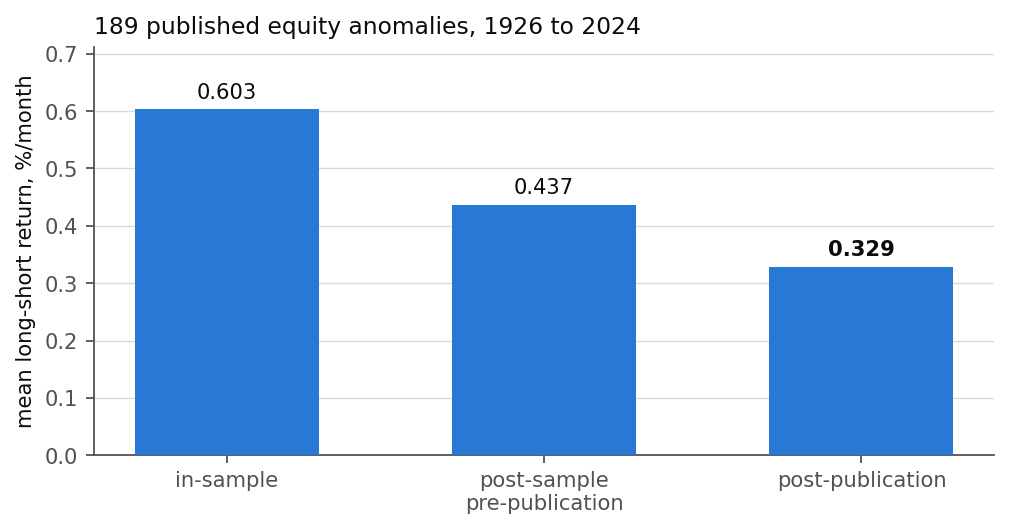

Figure 1: The published edge before and after publication. The same signals appear in all three bars.

```python
fig, ax = plt.subplots(figsize=(6.4, 3.4))
labels = ["in-sample", "post-sample\npre-publication", "post-publication"]
vals = [m1, m2, m3]
bars = ax.bar(labels, vals, color=BLUE, width=0.58, zorder=3)
for i, (b, v) in enumerate(zip(bars, vals)):
    ax.text(b.get_x() + b.get_width()/2, v + 0.012, f"{v:.3f}", ha="center", va="bottom",
            fontsize=9.5, color=INK, fontweight="bold" if i == 2 else "normal")
ax.set_ylabel("mean long-short return, %/month")
ax.set_title(f"{N_MATCHED} published equity anomalies, 1926 to 2024")
ax.grid(axis="x", visible=False)
ax.set_ylim(0, max(vals) * 1.18)
fig.tight_layout()
plt.show()
```

The mean falls 45 percent and the median 53 percent. The gap between the two is a finding in itself. A minority of signals survive more or less intact and pull the average up; the typical signal does worse than the average suggests.

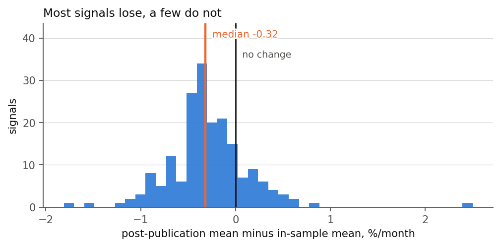

Figure 2: Change in each signal’s mean return from the in-sample window to the post-publication window. Left of zero is decay.

```python
chg = (table["post_pub"] - table["in_sample"])
fig, ax = plt.subplots(figsize=(6.4, 3.2))
counts, _, _ = ax.hist(chg.clip(-2.5, 2.5), bins=40, color=BLUE, alpha=0.9, zorder=3)
ax.set_ylim(0, counts.max() * 1.28)
ax.axvline(0, color=INK, lw=1.2, zorder=4)
ax.axvline(chg.median(), color=ORANGE, lw=2, zorder=5)
ax.annotate(f"median {chg.median():+.2f}", xy=(chg.median(), counts.max() * 1.20),
            xytext=(6, 0), textcoords="offset points", ha="left", va="center",
            color=ORANGE, fontsize=9, path_effects=HALO, zorder=6)
ax.annotate("no change", xy=(0, counts.max() * 1.06), xytext=(6, 0),
            textcoords="offset points", ha="left", va="center",
            color=MUTED, fontsize=8.5, path_effects=HALO, zorder=6)
ax.set_xlabel("post-publication mean minus in-sample mean, %/month")
ax.set_ylabel("signals")
ax.set_title("Most signals lose, a few do not")
ax.grid(axis="x", visible=False)
fig.tight_layout()
plt.show()
```

151 of 189 (80 percent) earn less after publication than in sample, and 32 (17 percent) have a negative mean long-short return once public. 109 were already lower in window 2.

## 4.2 The panel regression

Table 2: Equation 1 with signal fixed effects absorbed by within-demeaning and standard errors clustered by date.

|  | Full panel (212 signals) | Matched panel (189) |
| --- | --- | --- |
| $\beta_1$ post-sample | -0.1449 (se 0.0747, t = -1.94) | -0.1277 (se 0.0752, t = -1.70) |
| $\beta_2$ post-publication | **-0.2718** (se 0.0531, **t = -5.12**) | -0.2518 (se 0.0548, t = -4.60) |
| implied vs. in-sample mean | -24% and -45% | -21% and -42% |
| clusters (months) | 1,188 | 1,188 |

McLean and Pontiff (2016) report about 26 percent post-sample and 58 percent post-publication over 97 anomalies. This universe is about twice as large and includes weaker and less replicated signals. That is the first explanation for the smaller numbers and it can be tested by re-running the design on their 97.

## 4.3 What the estimates do not show

Read Table 2 quickly and a conclusion suggests itself: $\beta_2$ is sharply estimated and $\beta_1$ is not, so publication is what kills the edge. That conclusion does not survive a test.

“Publication matters over and above the end of the sample” is the restriction $H_0: \beta_2 = \beta_1$, that is $R\beta = 0$ with $R = (-1,\;1)$. The standard error of $R\hat\beta$ comes from the same clustered covariance matrix, and it is not the sum of the two individual standard errors, because $\hat\beta_1$ and $\hat\beta_2$ covary:

$$\mathrm{se}\!\left(\hat\beta_2 - \hat\beta_1\right)
= \sqrt{R \widehat{\mathrm{Var}}(\hat\beta) R'}
= \sqrt{\widehat V_{11} + \widehat V_{22} - 2\widehat V_{12}} .
\tag{3}$$

Comparing two $t$-statistics, one significant and one not, does not test whether the coefficients differ. Equation 3 does.

```python
R = np.array([-1.0, 1.0])

def restriction(beta, V):
    diff = R @ beta
    se   = np.sqrt(R @ V @ R)
    return diff, se, diff / se

diff_f, sed_f, td_f = restriction(beta_f, V_f)
diff_m, sed_m, td_m = restriction(beta_m, V_m)
corr_f = V_f[0, 1] / np.sqrt(V_f[0, 0] * V_f[1, 1])
```

Table 3: Testing $\beta_2 = \beta_1$ on the same clustered covariance.

|  | $\hat\beta_2 - \hat\beta_1$, %/month | se | t |
| --- | --- | --- | --- |
| Full panel | -0.1269 | 0.0761 | **-1.67** |
| Matched 189 | -0.1241 | 0.0755 | -1.64 |

The incremental effect of publication, over and above the decline that had already happened by the time the original sample ended, is not significant at the 5 percent level (|t| = 1.67 against a critical value of 1.96). The estimated correlation between $\hat\beta_1$ and $\hat\beta_2$ is 0.33, so the difference is less precisely estimated than $\hat\beta_2$ alone.

The point estimates are consistent with publication being the operative channel. The data do not support that reading at conventional levels, and the three-window design does not separate the arbitrage channel from the selection channel in this universe. What the data do support: the post-publication decline is precisely estimated, the post-sample decline is not, and the difference between them is too imprecise to claim.

A second limitation concerns calendar time. Publication years in this universe cluster between the early 1990s and the mid-2010s, so for most signals “after publication” also means “after about 2001”. Chordia, Subrahmanyam, and Tong (2014) document a decline in anomaly returns across the board after decimalization, with growth in hedge fund assets, short interest and turnover as the drivers. A specification with calendar-time fixed effects separates the two, and with staggered publication dates it is identified from the timing differences across signals. The next subsection runs it, with an estimator built for staggered dates.

## 4.4 A cohort-robust estimate

Equation 1 is a two-way fixed effects regression with staggered adoption. Goodman-Bacon (2021) shows that its post coefficient is a weighted average of every two-group comparison in the panel, including the ones that use already-published signals as controls for signals published later. When the effect changes with time since publication, and a decline that goes on for years is such an effect, those comparisons subtract the early signals’ deepening decline from the later signals’ estimate. Sun and Abraham (2021) fit one set of event-time dummies per publication cohort, with a reference bin and a control cohort left out, and average the cohort estimates within each bin with the cohort’s share of that bin. Each cohort estimate is then a comparison with signals not yet published, in the same calendar months, and the calendar-month effects absorb the common decline.

**read the Sun-Abraham estimates written by 02_decay_panel.py**

```python
sa1 = pd.read_csv(OUT / "result1_sunabraham.csv")
SA1_CUTOFFS = list(dict.fromkeys(sa1["control_cutoff"]))
SA1_MAIN = SA1_CUTOFFS[0]
SA1_BINS = [b for b in dict.fromkeys(sa1["term"]) if b != "post"]

def sa1_row(cutoff, est, term):
    r = sa1[(sa1["control_cutoff"] == cutoff) & (sa1["estimator"] == est) & (sa1["term"] == term)]
    return r.iloc[0]

sa1_main = sa1_row(SA1_MAIN, "sun_abraham", "post")
tw1_main = sa1_row(SA1_MAIN, "twfe_pooled", "post")

def fz(x, d=3, sign=True):
    """Format a number, with no minus sign on a value that rounds to zero."""
    v = f"{x:+.{d}f}" if sign else f"{x:.{d}f}"
    return v.replace("-", "+" if sign else "") if float(v) == 0 else v

def ct(x, d=3):
    return f"{fz(x, d)} ({fz(x, 1, sign=False) if abs(x) < 5e-2 else f'{x:.1f}'})"
```

Every signal in this universe is eventually published, so there is no never-treated group. The control cohort is the last-published one: the 14 signals published in 2014 or later, and the sample ends in 2013-12, the month before the first of them is published. That is the cost of the design in plain terms: the last decade of post-publication data, which has no not-yet-published signal to compare against, drops out. Two other cutoffs are reported so the reader sees the trade between window length and control size. Event time is measured from publication in five-year bins, with the five years before publication as the reference. Publication comes a median four years after the paper’s sample ends, so the reference bin sits mostly inside the post-sample window, and the earlier bins show the in-sample level against it. Standard errors are clustered by signal and by month; when the two-way matrix is not positive semi-definite the within-cell term is not subtracted, which is conservative, and the table says where that happened. The pooled two-way fixed effects bins on the same sample and controls are shown beside the Sun-Abraham bins.

Table 4: Monthly long-short return in event time around publication, %/month relative to the five years before publication. Sun-Abraham and the pooled two-way fixed effects bins on the same sample. Post: the average over all post-publication cells, cross-bin covariances included. Pre-trend: joint test that the pre-publication bins are zero.

| Years since publication | 2014, SA | 2014, TWFE | 2016, SA | 2016, TWFE | 2011, SA | 2011, TWFE |
| --- | --- | --- | --- | --- | --- | --- |
| -11 or earlier | +0.108 (0.7) | +0.157 (1.8) | +0.113 (0.6) | +0.161 (1.7) | +0.086 (0.7) | +0.143 (1.7) |
| -10 to -6 | +0.073 (0.6) | +0.111 (1.4) | +0.040 (0.3) | +0.085 (1.0) | +0.104 (0.9) | +0.145 (1.6) |
| 0 to 4 | -0.035 (-0.3) | -0.123 (-1.6) | -0.014 (-0.1) | -0.139 (-1.9) | -0.073 (-0.6) | -0.106 (-1.2) |
| 5 to 9 | +0.130 (0.8) | -0.021 (-0.2) | +0.235 (1.4) | -0.017 (-0.2) | +0.054 (0.3) | -0.058 (-0.5) |
| 10 to 14 | +0.086 (0.4) | -0.139 (-1.1) | +0.161 (0.7) | -0.111 (-1.0) | +0.091 (0.5) | -0.140 (-0.9) |
| 15+ | +0.124 (0.5) | -0.262 (-1.4) | +0.138 (0.5) | -0.296 (-1.8) | +0.069 (0.3) | -0.294 (-1.3) |
| **post, all bins** | +0.054 (0.4) | -0.120 (-1.6) | +0.112 (0.8) | -0.127 (-1.7) | +0.001 (0.0) | -0.127 (-1.5) |

Samples: cutoff 2014: sample to 2013-12, 198 treated and 14 control signals, 32 cohorts, pre-trend p = 0.78; cutoff 2016: sample to 2015-12, 208 treated and 4 control signals, 34 cohorts, pre-trend p = 0.76; cutoff 2011: sample to 2010-12, 171 treated and 41 control signals, 29 cohorts, pre-trend p = 0.69. The conservative covariance applies to the Sun-Abraham columns at every cutoff.

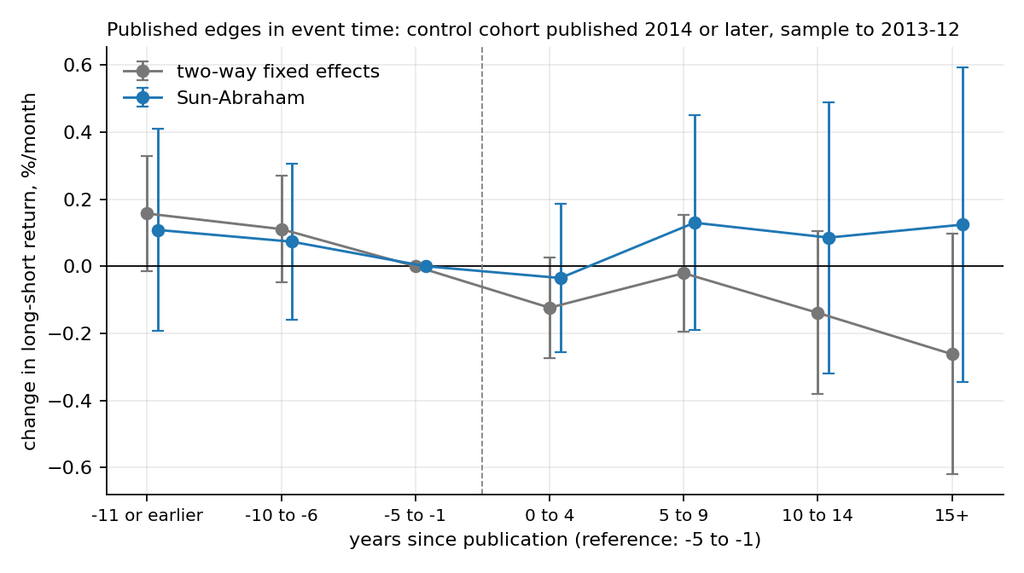

Figure 3: Event-time coefficients for the main cutoff, with 95 percent bands. Grey: pooled two-way fixed effects on the same sample. Blue: Sun-Abraham.

The cohort-robust estimate of the publication effect is zero. Against the five years before publication, the post-publication average is +0.054 percent a month (t = 0.42) at the main cutoff, and +0.112 (t = 0.76), +0.001 (t = 0.01) at the other two; no post bin is distinguishable from zero at any cutoff. The two-way fixed effects bins on the same sample give -0.120 (t = -1.56), which is the post-publication minus post-sample difference of Table 3 again, and the cohort-robust version removes it. The in-sample bins sit above the reference by 0.11 and 0.07 percent a month, the direction of the decline in Table 1, with bands that include zero. The standard errors are about twice those of the pooled regression, which is the price of estimating thirty cohorts separately and clustering two ways.

What this adds to Section 4. The 45 percent decline from the in-sample window to the post-publication window is a comparison of levels and stands. The claim that publication itself takes the return down further, beyond where it already was in the years before the paper appeared, was not significant in the three-window regression and is zero in the estimator built for staggered dates. The design does not identify an effect of publication in this universe, and the cohort-robust estimate says so more plainly than the first one did.

# 5 Rebuilding two signals from CRSP

Everything above is computed from return series that somebody else constructed. We therefore rebuild two signals from security-level CRSP data and score them month by month against the published versions: `Size`, about the simplest anomaly there is, and `Mom12m`, which has a formation window, a skip month and overlapping holding periods and is easy to get subtly wrong.

The pull (`03_crsp_pull.py`) and the rebuild (`04_build_anomalies.py`) need a WRDS subscription. This section reads the committed result files and needs nothing.

## 5.1 Portfolio construction

At each formation month $m$ the cross-section is sorted on the signal and cut into $n = 1/q$ buckets, where $q$ comes from `SignalDoc`: $q = 0.5$ for `Size`, because Banz (1981) splits the market in two, and $q = 0.1$ for `Mom12m`. For a bucket $B_m$ and a horizon $h$,

$$\bar r^{\,B}_{m,h} \;=\;
\frac{\sum_{i \in B_m} w_{i,m}\, r_{i,\,m+h}}{\sum_{i \in B_m} w_{i,m}} ,
\qquad
\mathrm{LS}^{(h)}_{m} \;=\; s \cdot
\Bigl( \bar r^{\,\mathrm{top}}_{m,h} - \bar r^{\,\mathrm{bot}}_{m,h} \Bigr),$$

with $w_{i,m} = 1$ for equal weighting and $w_{i,m} = \mathrm{mthcap}_{i,m}$ for value weighting, and $s = \pm 1$ the sign from `SignalDoc`. For `Size` the sign is $-1$: the anomaly is small minus big, and reversing it produces a significant result with the wrong label.

`Portfolio Period` is a holding period with overlapping cohorts (Jegadeesh and Titman 1993). The return booked in calendar month $c$ averages the cohorts formed at $c-1, \dots, c-H$,

$$\mathrm{LS}_{c} \;=\; \frac{1}{H}\sum_{h=1}^{H} \mathrm{LS}^{(h)}_{\,c-h} .
\tag{4}$$

The momentum signal is the twelve-month return ending one month before formation,

$$s^{\mathrm{mom}}_{i,m}
\;=\;
\exp\!\Biggl(\;\sum_{\tau = m-k-11}^{\,m-k} \log\bigl(1 + r_{i\tau}\bigr)\Biggr) - 1,
\qquad k = 1 ,
\tag{5}$$

defined only where the stock has a contiguous monthly record across the window. `Size` is $s^{\mathrm{size}}_{i,m} = \log(\mathrm{mthcap}_{i,m})$.

## 5.2 The comparison

**read the committed rebuild results**

```python
def load_rebuild(name, col):
    df = pd.read_csv(OUT / f"rebuild_{name}.csv")
    o  = df.dropna(subset=[col, "theirs"]).copy()
    o["gap"] = o[col] - o["theirs"]
    o["year"] = [ym(v)[0] for v in o["mi"]]
    return o

reb = {"Size": load_rebuild("Size", "mine"),
       "Mom12m": load_rebuild("Mom12m", "mine_hold1")}
COL = {"Size": "mine", "Mom12m": "mine_hold1"}

def gap_t(o):
    g = o["gap"].to_numpy()
    return g.mean(), g.std(ddof=1) / np.sqrt(len(g))

def corr(o, name):
    return float(np.corrcoef(o[COL[name]], o["theirs"])[0, 1])
```

Table 5: Rebuilt from CRSP against the published series, on the common overlap window.

|  | rebuilt, %/month | Chen and Zimmermann | difference | corr | months |
| --- | --- | --- | --- | --- | --- |
| **Size** (EW, halves, hold 12) | 0.324 | 0.322 | +0.002 (t = +0.16) | 0.992 | 1,182 |
| **Mom12m** (EW, deciles, hold 1) | 0.791 | 0.899 | -0.107 (t = -1.82) | 0.972 | 1,174 |

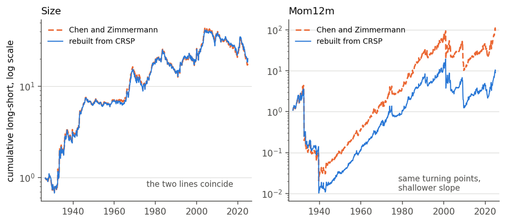

Figure 4: Cumulative long-short value of one dollar, log scale. Rebuilt from CRSP against the published series.

```python
fig, axes = plt.subplots(1, 2, figsize=(7.6, 3.4))
for ax, name in zip(axes, ["Size", "Mom12m"]):
    o = reb[name]; x = mi_to_ts(o["mi"])
    a = (1 + o[COL[name]] / 100).cumprod().to_numpy()
    b = (1 + o["theirs"] / 100).cumprod().to_numpy()
    ax.plot(x, b, color=ORANGE, lw=1.5, ls=(0, (4, 2)), zorder=2,
            label="Chen and Zimmermann")
    ax.plot(x, a, color=BLUE,   lw=1.1, label="rebuilt from CRSP", zorder=3)
    ax.set_yscale("log"); ax.set_title(name)
    ax.grid(axis="x", visible=False); ax.margins(x=0.02)
    ax.legend(loc="upper left", fontsize=8)

axes[0].set_ylabel("cumulative long-short, log scale")
axes[0].annotate("the two lines coincide", xy=(0.50, 0.08), xycoords="axes fraction",
                 fontsize=8.5, color=MUTED)
axes[1].annotate("same turning points,\nshallower slope", xy=(0.52, 0.06),
                 xycoords="axes fraction", fontsize=8.5, color=MUTED)
fig.tight_layout()
plt.show()
```

Size reproduces almost exactly: a difference of +0.002 percent a month over 1,182 months, correlation 0.992. In Figure 4 the two lines are hard to tell apart across a century.

Momentum reproduces in shape and comes in light in level. The right-hand panel shows two lines with the same turning points and different slopes, which on a log scale is a roughly constant per-month shortfall.

## 5.3 Is the momentum gap real?

```python
o = reb["Mom12m"]
mg, sg = gap_t(o)
sd_gap = o["gap"].std(ddof=1)

# 1. thin pre-1963 data, when CRSP covers NYSE only?
pre, post = o[o["year"] < 1963], o[o["year"] >= 1963]
(mpre, spre), (mpost, spost) = gap_t(pre), gap_t(post)

# 2. a uniform implementation difference, present every month?
share_below = (o["gap"] < 0).mean()

# 3. or a tail?
worst   = o.reindex(o["gap"].abs().sort_values(ascending=False).index)
share60 = worst.head(60)["gap"].sum() / len(o) / mg
cut     = o["gap"].abs().quantile(0.90)
trim_all  = o[o["gap"].abs() <= cut]["gap"].mean()
cut_pre   = pre["gap"].abs().quantile(0.90)
trim_pre  = pre[pre["gap"].abs() <= cut_pre]["gap"].mean()
corr_abs  = float(np.corrcoef(o["gap"].abs(), o["theirs"].abs())[0, 1])
```

A momentum long-short series is volatile, and so is the month-by-month difference between two implementations of one. The gap has a standard deviation of 2.03 percent a month, so a mean of -0.107 over 1,174 months carries t = -1.82. Before 1963 it is t = -0.74; from 1963 on, t = -1.94. Neither period rejects equality.

We checked three explanations.

First, thin early data. CRSP covers NYSE only until mid-1962, so the natural guess is that the gap sits before 1963 and the modern period replicates cleanly. It does not. The gap is -0.092 before 1963 and -0.116 after.

Second, a uniform implementation difference. If a slightly different screen produced a slightly different portfolio every month, the sign of the difference would be persistent. The rebuilt series is below the published one in 53.0 percent of months, a coin flip.

Third, a tail. The 60 months with the largest absolute gap, 5 percent of the sample, carry 100 percent of the mean difference. Trimming the largest decile of months takes the full-sample gap to -0.051 and flips the pre-1963 gap to +0.068. The absolute gap correlates 0.37 with the absolute size of that month’s published return.

Table 6: The eight months that carry the momentum difference.

| Month | rebuilt | published | difference |
| --- | --- | --- | --- |
| 1939-11 | -1.42 | 15.84 | -17.27 |
| 1932-12 | -0.99 | 15.12 | -16.11 |
| 1939-09 | -92.69 | -78.23 | -14.47 |
| 1942-01 | -27.06 | -15.32 | -11.74 |
| 1943-01 | 4.78 | 16.19 | -11.41 |
| 1931-01 | -26.37 | -16.16 | -10.21 |
| 1933-06 | -7.88 | 1.86 | -9.74 |
| 1933-05 | -40.68 | -50.22 | +9.54 |

All eight fall between 1931 and 1943, in the momentum crashes and rebounds of the Depression and the war years, when past losers surge and the extreme deciles turn over violently (Daniel and Moskowitz 2016). September 1939 is the rebound at the outbreak of war, and the 1932 and 1933 months are the largest momentum reversals on record. The post-war crash months rank lower: December 2008 is 14th by absolute gap and March 2009 is 17th. In months like these a single imputed price, or one stock that delists inside a holding period, moves a bucket mean by percentage points, and two implementations of a decile sort part company. Shumway (1997) is the classic statement of how much the treatment of disappearing stocks matters.

We tried no screen variants. The remaining 0.107 percent a month could be closed by searching filter combinations until the rebuilt series matched the published one. That would be fitting the replication to its target, and it is the behaviour this paper sets out to measure. One signal reproduces exactly; the other reproduces to within sampling error.

## 5.4 A definition error that correlation did not catch

`SignalDoc` defines `Mom12m` over “months t-12 and t-1”. Month $t$ is excluded, which is the $k = 1$ in Equation 5. Our first implementation used $m-11,\dots,m$, which pulls short-term reversal (Jegadeesh 1990) into a momentum signal. Last month’s return is negatively autocorrelated, so including it adds an effect of the opposite sign.

```python
# `mine` and `mine_noskip` both use the documented three-month holding period. They
# differ in one thing only: whether month t is inside the formation window.
ns = (pd.read_csv(OUT / "rebuild_Mom12m.csv")
        .dropna(subset=["mine", "mine_noskip", "theirs"]))
mean_skip   = ns["mine"].mean()
mean_noskip = ns["mine_noskip"].mean()
mean_theirs = ns["theirs"].mean()
corr_noskip = float(np.corrcoef(ns["mine_noskip"], ns["theirs"])[0, 1])
```

With everything else fixed at the documented three-month holding period, dropping the skip takes the long-short mean from 0.652 to 0.459 percent a month, against a published 0.899. Rebalanced monthly, where no cohort skips at all, the mean fell to -0.009 percent a month: the premium disappeared.

The correlation with the published series stayed at 0.974 throughout, peaking at lag 0. Correlation confirms that the merge and the calendar are right. It says nothing about whether the signal definition is right, because a signal formed on the wrong window is still mostly the same portfolio. Only the level catches this.

# 6 Can a model pick the survivors in real time?

The decay in this section is the one measured above: the decline in a published signal’s monthly long-short return over the years after publication. We ask a forecasting question about it. Standing in a given month, knowing only the signals that had been published by then, could a forecaster have picked the ones that would pay next month, and does a flexible model do this better than a linear one?

The question is the allocator’s. A fund that trades published signals has to decide, every month, which of them to keep. It also tests the mechanism from a different angle. If decay is a predictable function of time since publication, a model given that clock should use it. If the information is already in the signal’s own return history, the clock should add nothing once that history is in the model.

## 6.1 Information set and panel

One row is a signal in a month; the target is that signal’s long-short return next month. A forecaster in month $t$ knows which signals have been published (publication year strictly before the year of $t$), each published signal’s documented sample window and the characteristics of its paper, and each published signal’s return history up to $t$, including the months before the paper appeared, since a public recipe can be backfilled. The forecaster knows nothing about signals not yet published. A signal therefore enters the panel, for training and for testing, only in the years after its publication year. This is the whole of the no-look-ahead rule, and it removes most of the sample before 1995, when fewer than two dozen signals were public.

**read the committed results of 05_ml_panel.py**

```python
r2   = pd.read_csv(OUT / "ml_r2.csv", index_col=0)
dm   = pd.read_csv(OUT / "ml_dm.csv")
port = pd.read_csv(OUT / "ml_portfolio.csv", index_col=0)
port.index = pd.PeriodIndex(port.index, freq="M")
imp  = pd.read_csv(OUT / "ml_importance.csv", index_col=0)
curve = pd.read_csv(OUT / "ml_decay_curve.csv", index_col=0)
tuning = pd.read_csv(OUT / "ml_tuning.csv")

LAB = {"zero": "zero forecast", "own_mean": "own historical mean", "ols": "OLS",
       "enet": "elastic net", "gbrt": "gradient boosted trees",
       "mlp": "neural network (16 units)"}
MODELS = ["zero", "own_mean", "ols", "enet", "gbrt", "mlp"]
N_TEST = int(r2["n_test_rows"].iloc[0])

def perf(x):
    m, s = x.mean(), x.std(ddof=1)
    return m, s, (m / s) * np.sqrt(12), m / (s / np.sqrt(len(x)))

def dm_t(bench, model):
    return float(dm[(dm["benchmark"] == bench) & (dm["model"] == model)]["dm_t"].iloc[0])
```

Every model sees the same 27 features, all known at $t$:

- the signal’s own history: last month’s return, its mean over the past 12, 36 and 60 months and over its whole history, and its 12-month volatility;
- event time: months since the end of the paper’s sample, months since publication, and the two indicators that follow from them;
- the paper: publication year, length of the original sample, the $t$-statistic and mean return the original paper reported, the quantile cut, the holding period, whether the portfolio is value-weighted, whether the sort is on a discrete variable, the data type of the characteristic and whether the journal is one of the three top finance journals;
- market state, built from the panel itself: last month’s equal-weighted return across the signals that were public, and its 12-month mean and volatility.

Nothing comes from outside the two input files.

## 6.2 Models and validation

Two benchmarks fit nothing: a forecast of zero, and the signal’s own historical mean return. Against them we fit a linear regression, an elastic net, gradient boosted trees and a neural network with one hidden layer of 16 units, all in scikit-learn (Pedregosa et al. 2011). The design follows Gu, Kelly, and Xiu (2020): an expanding window with one refit per calendar year, test years 1995 to 2024; hyperparameters chosen on the last eight years of each training sample, after which the model is refit on the whole sample; and out-of-sample $R^2$ measured against a zero forecast. Time is kept by the target month. A test year collects the forecasts whose target month falls in that year, every row used to fit or tune the model for it has a target month before January of that year, and the code checks that boundary at each refit. The out-of-sample $R^2$ is

$$R^2_{\mathrm{oos}} \;=\; 1 - \frac{\sum_{i,t}\bigl(r_{i,t+1} - \hat r_{i,t+1}\bigr)^2}
{\sum_{i,t} r_{i,t+1}^{2}} .$$

We also report $R^2$ against the own-mean benchmark, which is the harder test. The tuning grids are small on purpose: nine settings for the elastic net, four for the trees with the number of trees chosen on the validation sample, two for the network with three random restarts averaged. Every setting tried is in `output/ml_tuning.csv`, 450 rows in all. Forecast accuracy is compared with the Diebold and Mariano (1995) test on the monthly average loss differential across signals, with a Newey and West (1987) variance at twelve lags.

## 6.3 Results

Table 7: Out-of-sample R², in percent, 1995 to 2024. Columns 3 to 5 split the test rows by years since publication.

| Model | vs. zero | vs. own mean | 0 to 3 years | 3 to 10 years | over 10 years |
| --- | --- | --- | --- | --- | --- |
| zero forecast | +0.00 | -0.62 | +0.00 | +0.00 | +0.00 |
| own historical mean | +0.62 | +0.00 | -0.06 | +0.42 | +0.80 |
| OLS | +0.84 | +0.23 | -0.50 | +0.27 | +1.28 |
| elastic net | +0.81 | +0.19 | -0.46 | +0.37 | +1.17 |
| gradient boosted trees | +0.88 | +0.26 | +0.41 | +0.53 | +1.10 |
| neural network (16 units) | -0.22 | -0.84 | -2.20 | -1.96 | +0.84 |

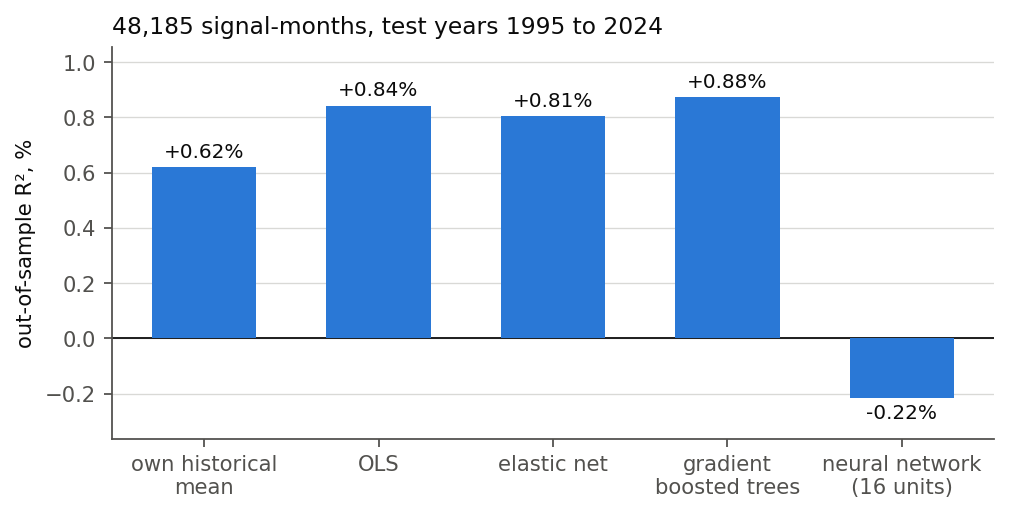

Figure 5: Out-of-sample R² against a zero forecast, pooled over all test rows.

```python
fig, ax = plt.subplots(figsize=(6.4, 3.3))
ms = ["own_mean", "ols", "enet", "gbrt", "mlp"]
names = ["own historical\nmean", "OLS", "elastic net", "gradient\nboosted trees",
         "neural network\n(16 units)"]
vals = [100 * r2.loc[m, "r2_vs_zero"] for m in ms]
ax.bar(names, vals, color=BLUE, width=0.6, zorder=3)
for i, v in enumerate(vals):
    ax.text(i, v + 0.02 if v >= 0 else v - 0.02, f"{v:+.2f}%", ha="center",
            va="bottom" if v >= 0 else "top", fontsize=9, color=INK)
ax.axhline(0, color=INK, lw=0.8)
ax.set_ylabel("out-of-sample R², %")
ax.set_title(f"{N_TEST:,} signal-months, test years 1995 to 2024")
ax.grid(axis="x", visible=False)
lo, hi = min(vals + [0]), max(vals + [0])
ax.set_ylim(lo - 0.15, hi + 0.18)
fig.tight_layout()
plt.show()
```

Three things stand out in Table 7.

The numbers are small. The linear regression explains 0.84 percent of next month’s variation, the trees 0.88 percent, and the own-mean benchmark alone 0.62 percent. This is the order of magnitude Gu, Kelly, and Xiu (2020) report for individual stocks at the monthly horizon; monthly long-short returns are mostly noise.

No model beats another by a margin a test can distinguish. Against the own-mean benchmark OLS adds 0.23 percent, the trees 0.26 percent and the network -0.84 percent. The Diebold-Mariano statistic for OLS against the own mean is -0.29, for the trees against OLS +0.42, and for the network against OLS -1.15. The tree number also depends on the tuning path: holding any one of the four grid settings fixed through all thirty refits gives an $R^2$ between 0.70 and 0.93 percent, so the gap between the trees and the linear model is inside the range the trees cover on their own. (The fit uses no subsampling, so a setting fixes the result; seeds play no role.) On this panel a model that can represent interactions and nonlinearities finds none that a test can see.

Predictability does not fall with age. The $R^2$ is as high for signals more than ten years past publication as for signals in their first three years. Whatever is predictable about a published signal’s next return is still predictable long after the paper.

Table 8: Permutation importance: the rise in pooled test mean squared error when a group of features is shuffled within each test year.

| Feature group | gradient boosted trees | OLS |
| --- | --- | --- |
| own history | +0.4225 | +0.5350 |
| market state | +0.0680 | -0.0031 |
| construction | +0.0111 | -0.0009 |
| original evidence | +0.0095 | +0.0003 |
| data type and journal | -0.0012 | -0.0016 |
| event time | -0.0111 | +0.0030 |

Table 8 says where the predictive content sits. Shuffling the signal’s own return history raises the test error by 0.423 for the trees and 0.535 for OLS. The next largest group for the trees is market state, at 0.068; every other group moves the error by less than 0.011 in either direction, and for several of them the error falls, which is what noise looks like under permutation. Event time in particular adds nothing once the signal’s own history is in the model.

## 6.4 The decay curve, conditional and unconditional

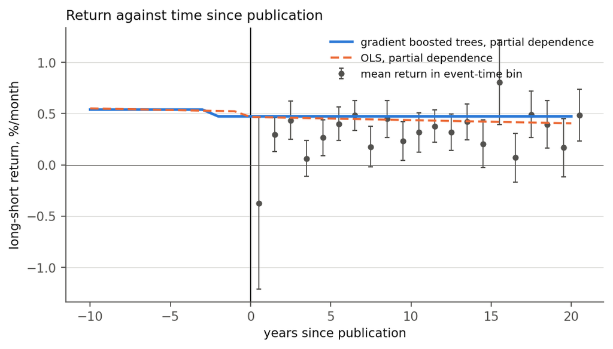

Figure 6: Long-short return against years since publication. Dots: mean return of the test rows in twelve-month bins of event time, with 95 percent bands. Lines: partial dependence of the final-year models on months since publication, holding every other feature at its sample values.

```python
raw = curve.dropna(subset=["mean"])
pdp = curve.dropna(subset=["pd_gbrt"])
fig, ax = plt.subplots(figsize=(6.6, 3.8))
ax.errorbar(raw.index / 12, raw["mean"], yerr=1.96 * raw["se"], fmt="o", ms=3.6,
            color=MUTED, capsize=2, lw=0.8, zorder=3, label="mean return in event-time bin")
ax.plot(pdp.index / 12, pdp["pd_gbrt"], color=BLUE, lw=2, zorder=4,
        label="gradient boosted trees, partial dependence")
ax.plot(pdp.index / 12, pdp["pd_ols"], color=ORANGE, lw=1.6, ls=(0, (4, 2)), zorder=4,
        label="OLS, partial dependence")
ax.axvline(0, color=INK, lw=0.8)
ax.axhline(0, color=MUTED, lw=0.5)
ax.set_xlabel("years since publication")
ax.set_ylabel("long-short return, %/month")
ax.set_title("Return against time since publication")
ax.legend(fontsize=8.2, loc="upper right")
ax.grid(axis="x", visible=False)
fig.tight_layout()
plt.show()
```

Figure 6 puts the two readings of decay side by side. The dots are unconditional: the average return of published signals in each year after publication, averaged across whatever signals were in the panel. They sit around 0.31 percent a month, close to the post-publication window mean in Table 1, and they show no trend over twenty years. The lines are conditional. They show what each model predicts as the publication clock moves while the signal’s own history and everything else is held fixed. The OLS line falls from 0.47 at publication to 0.41 twenty years later: the monthly return drops by about 0.3 basis points for each year that passes. The tree line is flat at 0.47.

The two readings are consistent. Decay shows up in the level of the dots relative to the in-sample mean in Table 1, which is the result of Section 4. It does not show up as a slope within the post-publication period, and it does not show up as a function of the clock once the model knows the signal’s recent returns. Whatever the publication date tells a forecaster is already in the return series by the time the forecaster could use it.

## 6.5 Choosing among published signals

Table 9: Portfolios formed each month from the published signals, 1995 to 2024. Monthly returns in percent; Sharpe ratios annualised.

| Portfolio | mean | vol | Sharpe | t |
| --- | --- | --- | --- | --- |
| own historical mean, top fifth | 0.712 | 1.815 | 1.36 | 7.44 |
| own historical mean, top fifth minus bottom fifth | 0.615 | 2.206 | 0.97 | 5.29 |
| OLS, top fifth | 1.028 | 3.802 | 0.94 | 5.13 |
| OLS, top fifth minus bottom fifth | 1.180 | 6.454 | 0.63 | 3.47 |
| elastic net, top fifth | 1.039 | 3.784 | 0.95 | 5.21 |
| elastic net, top fifth minus bottom fifth | 1.173 | 6.476 | 0.63 | 3.44 |
| gradient boosted trees, top fifth | 1.004 | 3.889 | 0.89 | 4.90 |
| gradient boosted trees, top fifth minus bottom fifth | 1.216 | 6.531 | 0.64 | 3.53 |
| neural network (16 units), top fifth | 0.993 | 3.506 | 0.98 | 5.37 |
| neural network (16 units), top fifth minus bottom fifth | 1.163 | 6.061 | 0.66 | 3.64 |
| **all published signals, equal-weighted** | **0.381** | **1.003** | **1.31** | **7.20** |

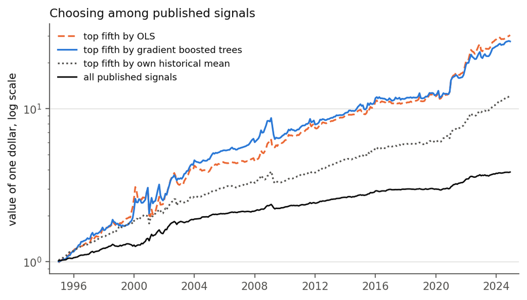

Figure 7: Cumulative value of one dollar in the top fifth of published signals, ranked each month by each forecast, against holding every published signal with equal weight.

```python
fig, ax = plt.subplots(figsize=(6.6, 3.8))
for m, color, ls in [("ols", ORANGE, (0, (4, 2))), ("gbrt", BLUE, "-"),
                     ("own_mean", MUTED, (0, (1, 1.5)))]:
    cum = (1 + port[f"{m}_top"] / 100).cumprod()
    ax.plot(cum.index.to_timestamp(), cum, color=color, ls=ls, lw=1.5,
            label=f"top fifth by {LAB[m]}", zorder=3)
cum = (1 + port["all"] / 100).cumprod()
ax.plot(cum.index.to_timestamp(), cum, color=INK, lw=1.3, label="all published signals",
        zorder=4)
ax.set_yscale("log")
ax.set_ylabel("value of one dollar, log scale")
ax.set_title("Choosing among published signals")
ax.legend(fontsize=8.2, loc="upper left")
ax.grid(axis="x", visible=False); ax.margins(x=0.02)
fig.tight_layout()
plt.show()
```

Table 9 is the allocator’s table. Holding every published signal with equal weight earns 0.38 percent a month at a volatility of 1.00, a Sharpe ratio of 1.31. Ranking signals by their own historical mean and holding the top fifth raises the mean to 0.71 and the Sharpe ratio to 1.36. Ranking by the OLS forecast raises the mean further, to 1.03, and doubles the volatility, so the Sharpe ratio falls to 0.94; the trees give 1.00 and 0.89. The models earn their higher mean by selecting volatile signals, and a mean-squared-error forecast of return has no reason to care about volatility. The long-short versions of these portfolios, which also short the bottom fifth, have the same character.

Three cautions. These are portfolios of long-short portfolios and carry no trading costs; Chen and Velikov (2023) show how much of a published anomaly’s gross return the costs take. The return to “the top fifth by own mean” is the return to persistence in the cross-section of published anomalies, which is a statement about the data, not a strategy we would expect to survive its own publication. And the own-mean Sharpe ratio is sensitive to one detail of the universe rule: a signal published in year $y-1$ first enters in the December feature month of that year, which forecasts January $y$. Those first-month rows, 189 in all, carry high historical means, are often selected into the top fifth, and earn little; with them the top-fifth Sharpe ratio is 1.36, and under a rule that admits a signal only from the following February it is 1.52.

## 6.6 What this section does and does not show

It shows that, in real time and without look-ahead, next month’s return on a published signal is weakly predictable, that the predictability is linear and lives in the signal’s own history, and that a model with no access to the publication date would do as well as one with it. It does not show that machine learning cannot find structure in anomaly returns: the features here are coarse, the panel has about 48,000 test rows, and a model given the underlying stock-level data would face a different problem. It also does not touch the horizon a trading desk means by decay, which would need daily or intraday portfolio returns.

# 7 Stock-level forecasts with and without look-ahead

The panel above has one row per published signal and about 48,000 test rows. The question is usually asked one level down, on individual stocks, with the characteristics as features (Gu, Kelly, and Xiu 2020), and that is where the two things this paper cares about can be measured directly. The first is look-ahead in the choice of features. A model fitted today on every characteristic that has ever been published uses, in 1995, characteristics whose papers appeared in 2010. The gap between that model and one restricted to the characteristics that were public at the time is what a forecaster gains from knowing today which characteristics would later be published. The second is what the model does with a characteristic once it is public. If publication competes an edge away, a model refit each year should lean less on a characteristic after its paper appears.

## 7.1 Data and two decisions made before the models ran

**read the committed outputs of 07_stage1_models.py and 08_stage1_eventtime.py**

```python
import json
S1_RUN = json.loads((OUT / "stage1_run.json").read_text())
s1_r2 = pd.read_csv(OUT / "stage1_r2.csv")
s1_r2_all = s1_r2[s1_r2["year"].astype(str) == "all"].set_index(["model", "set", "universe"])["r2"]
s1_n = s1_r2[s1_r2["year"].astype(str) == "all"].groupby("universe")["n"].first()
s1_ic = pd.read_csv(OUT / "stage1_ic.csv").set_index(["model", "set", "universe"])
s1_dm = pd.read_csv(OUT / "stage1_dm.csv")
s1_port = pd.read_csv(OUT / "stage1_portfolio_summary.csv").set_index(["model", "set", "weighting", "universe"])
s1_sp = pd.read_csv(OUT / "stage1_spreads_panel.csv").set_index("size_grp")
s1_tr = pd.read_csv(OUT / "stage1_spreads_traded.csv")
s1_tgt = pd.read_csv(OUT / "stage1_target.csv")
s1_top = pd.read_csv(OUT / "stage1_target_top.csv")
s1_ev = pd.read_csv(OUT / "stage1_eventtime.csv")
s1_chars = pd.read_csv(ROOT / "jkp_characteristics.csv")
s1_tuning = pd.read_csv(OUT / "stage1_tuning.csv")

S1_MODELS = ["huber", "enet", "pcr", "pls", "gbrt", "gbrth", "nn1", "nn2", "nn3"]
S1_LAB = {"huber": "Huber regression", "enet": "elastic net", "pcr": "principal components",
          "pls": "partial least squares", "gbrt": "boosted trees, squared loss",
          "gbrth": "boosted trees, Huber loss", "nn1": "network, 1 layer",
          "nn2": "network, 2 layers", "nn3": "network, 3 layers"}
SIZE_ORDER = ["mega", "large", "small", "micro", "nano"]
S1_FIRST, S1_LAST = S1_RUN["flags"]["first_test"], S1_RUN["flags"]["last_test"]
N_CHARS = len(s1_chars)
N_PUBLIC_FIRST = int((s1_chars["pub_year"] < S1_FIRST).sum())
YEAR_ALL_PUBLIC = int(s1_chars["pub_year"].max()) + 1
N_INSIDE = int(s1_chars["pub_year"].between(S1_FIRST, S1_LAST).sum())
N_TEST_S1 = int(s1_n["all"])
SHARE_SMALL = 1 - s1_n["ex_small"] / s1_n["all"]

def s1_dm_t(model, s, bench):
    r = s1_dm[(s1_dm["model"] == model) & (s1_dm["set"] == s) & (s1_dm["benchmark"] == bench)]
    return float(r["dm_t"].iloc[0])

def ev(model, outcome, term, col, spec="post"):
    r = s1_ev[(s1_ev["model"] == model) & (s1_ev["outcome"] == outcome) & (s1_ev["spec"] == spec)
              & (s1_ev["term"] == term)]
    return float(r[col].iloc[0])

# the target diagnostic that fixed the first decision
dominated = s1_tgt[s1_tgt["share_sq_top1"] > 0.5]
top1 = s1_top[s1_top["rank"] == 1]
top1_dom = top1[top1["year"].isin(dominated["year"])]
```

The panel is the United States part of the Jensen, Kelly, and Pedersen (2023) global factor data on WRDS: common stocks on the main exchanges, one primary security per firm, from 1963 to 2025. The target is next month’s excess return. The features are the 153 characteristics in that dataset for which a publication year is recorded, each ranked within its month across the whole universe and mapped to $[-1, 1]$, with missing values at zero. Two information sets are fitted on the same rows with the same grids and seeds. The *public* set holds the characteristics whose paper appeared before the test year, 21 of them in 1995; the *full* set holds all 153, which is the usual setup and contains look-ahead. The two sets coincide from 2021 on, so the gap between them is identified from the earlier test years. Test years run from 1995 to 2024; the forecasts made at the end of December 2024, which target January 2025, fall outside the window. Time is kept by the target month as in Section 6: training rows have target months before the validation block, the validation block is the eight years before the test year, and nothing is refit after validation, so the model scored on a test year is the one that was early-stopped or selected on the validation years.

Two decisions were made from diagnostics before any model was scored, and both changed the design.

The first concerns the target. The realised returns carry a few absurd values. In 12 of the 30 test years one stock-month holds more than half of the year’s total squared return, and the largest single share is 99.99 percent. A table of those rows by category, written before any model ran (`output/stage1_target.csv`), shows what they are: in 12 of the 12 dominated years the largest row has no CRSP return and no CRSP identifier, and in 11 of them the price is under ten cents. They are Compustat-sourced rows for securities CRSP does not cover. The remedy that follows is the one applied: the panel keeps only rows whose return comes from CRSP, which removes 2.5 percent of stock-months on average; the fitting and selection targets are clipped at the 0.1 and 99.9 percentiles of the training returns, except for the Huber regression, whose loss is its own protection; and every forecast is scored against the raw realised return. Because the tails sit in particular rows, the $R^2$ is reported on three row sets: all 1,909,533 test rows, the rows outside the micro and nano size groups, and the rows whose realised return is inside $\pm 100$ percent. A result that holds on one set and not another is reported as such.

The second concerns trading costs, and is described with the portfolios below.

## 7.2 Models

The models are those of Gu, Kelly, and Xiu (2020), in the same spirit of small grids: a Huber regression on all features, an elastic net, principal-component and partial-least-squares regressions, gradient boosted trees (Ke et al. 2017), and feed-forward networks with one, two and three hidden layers of 32, 16 and 8 units, each an average over five seeds. The trees are fitted twice, once with squared loss and once with a Huber loss, because the two disagree in a way the reader should see: the Huber-loss trees centre their forecasts below the realised mean, which gives them a negative $R^2$ against a zero forecast and, at the same time, the highest rank correlation with realised returns of any model. Both are reported. Every setting tried is in `output/stage1_tuning.csv`, 540 rows.

## 7.3 Forecast accuracy

Table 10: Out-of-sample R² against a zero forecast, in percent, pooled over the test years. Public: characteristics published before the test year. Full: all characteristics. Three row sets, as described in the text.

| Model | all, public | all, full | ex micro and nano, public | ex micro and nano, full | abs. return under 100%, public | abs. return under 100%, full |
| --- | --- | --- | --- | --- | --- | --- |
| Huber regression | +0.17 | +0.27 | -0.06 | +0.06 | +0.26 | +0.49 |
| elastic net | +0.21 | +0.33 | +0.12 | +0.29 | +0.23 | +0.47 |
| principal components | +0.19 | +0.22 | +0.11 | +0.24 | +0.26 | +0.39 |
| partial least squares | +0.21 | +0.32 | +0.09 | +0.25 | +0.32 | +0.54 |
| boosted trees, squared loss | +0.29 | +0.34 | -0.05 | +0.04 | -0.08 | +0.08 |
| boosted trees, Huber loss | -0.29 | -0.35 | -0.13 | -0.09 | +0.49 | +0.51 |
| network, 1 layer | +0.29 | +0.46 | +0.16 | +0.30 | +0.22 | +0.45 |
| network, 2 layers | +0.33 | +0.52 | +0.27 | +0.44 | +0.29 | +0.47 |
| network, 3 layers | +0.37 | +0.55 | +0.32 | +0.47 | +0.35 | +0.53 |

Table 11: Rank IC: the monthly Spearman correlation between forecast and realised return, averaged over the test months, with a Newey-West t-statistic at twelve lags. Added after the first pass, when the R² turned out to depend on a handful of rows.

| Model | all, public | all, full | ex micro and nano, public | ex micro and nano, full |
| --- | --- | --- | --- | --- |
| Huber regression | 0.074 (12.6) | 0.084 (12.2) | 0.040 (5.8) | 0.047 (6.2) |
| elastic net | 0.073 (12.4) | 0.084 (11.6) | 0.041 (5.7) | 0.048 (5.8) |
| principal components | 0.072 (7.4) | 0.086 (9.7) | 0.037 (4.4) | 0.044 (5.0) |
| partial least squares | 0.082 (9.9) | 0.095 (10.7) | 0.042 (5.2) | 0.051 (5.7) |
| boosted trees, squared loss | 0.070 (12.7) | 0.074 (12.5) | 0.035 (4.7) | 0.035 (4.7) |
| boosted trees, Huber loss | 0.110 (11.7) | 0.113 (11.6) | 0.048 (5.3) | 0.049 (5.1) |
| network, 1 layer | 0.070 (13.8) | 0.077 (13.5) | 0.042 (6.8) | 0.048 (7.2) |
| network, 2 layers | 0.075 (13.0) | 0.081 (13.5) | 0.045 (6.5) | 0.052 (7.3) |
| network, 3 layers | 0.079 (12.7) | 0.084 (13.2) | 0.046 (6.4) | 0.052 (6.9) |

The level is the one Gu, Kelly, and Xiu (2020) report for monthly stock returns. Against a zero forecast the full-information models explain between 0.22 and 0.55 percent of next month’s variation on all rows, the three-layer network highest at 0.55 percent and the Huber regression at 0.27.

Finally, 56 percent of the stock-months are micro or nano caps, and the forecasts are weaker outside them: the rank IC falls by about half and the Huber regression’s $R^2$ on that set is 0.06 percent. The portfolios below make the same point in dollars.

## 7.4 Portfolios and the cost of trading them

Each month the stocks are sorted into deciles on the forecast, the top decile is held long and the bottom decile short, equal- or value-weighted, with and without the micro and nano groups. Turnover is half the sum of absolute weight changes, and each traded dollar is charged half a spread.

The second decision is which spread. The first pass charged half of the Corwin and Schultz (2012) estimate that comes with the panel, averaged over 21 days. The traded-weighted spread it implied in a value-weighted book was about one percent, which is too high after 2001 for stocks above the NYSE 20th size percentile, and the estimate is noisy and floored at zero, which pushes its mean up. The cost measure in this section is therefore the month’s mean closing quoted spread from the CRSP daily file, $(\text{ask} - \text{bid}) / \text{midpoint}$ on days with a positive quote, which Chung and Zhang (2014) show tracks TAQ effective spreads closely; for liquid stocks it is itself an upper bound, since trades print inside the quote. A quoted spread exists for 99.1 percent of the test stock-months (between 98.7 and 99.2 percent across the size groups) and prices at least 94 percent of traded weight in every book; the Corwin-Schultz estimate fills the gap. Corwin-Schultz is also reported as a bound: for every size group outside nano it is above the quoted spread, by a factor of about ten at the mega-cap median, so the net Sharpe ratio under it is a conservative reading for a value-weighted book. In the nano group it is below the quoted spread, so it is not a bound there. The Abdi and Ranaldo (2017) estimate from daily high, low and close is a third reading that needs no quotes.

Table 12: Full spreads over the test rows, by size group, in percent. Medians of the CRSP closing quoted spread (the cost measure), the Corwin-Schultz estimate (the bound) and the Abdi-Ranaldo estimate; then, for the value-weighted Huber book on all rows, each group’s share of traded weight and the traded-weighted spread on the two series.

| Size group | quoted, median | Corwin-Schultz, median | Abdi-Ranaldo, median | share of traded weight | traded-weighted spread, quoted | traded-weighted spread, Corwin-Schultz |
| --- | --- | --- | --- | --- | --- | --- |
| mega | 0.05 | 0.55 | 0.24 | 60.9 | 0.24 | 0.70 |
| large | 0.09 | 0.66 | 0.24 | 21.1 | 0.42 | 0.88 |
| small | 0.20 | 0.89 | 0.49 | 11.6 | 0.68 | 1.13 |
| micro | 1.30 | 1.40 | 1.30 | 5.7 | 1.68 | 1.66 |
| nano | 3.74 | 2.61 | 2.91 | 0.3 | 4.90 | 3.23 |

Table 12 is why the choice matters. For mega and large caps the quoted spread median is 0.05 and 0.09 percent against Corwin-Schultz medians of 0.55 and 0.66; the two agree in the micro group and reverse in the nano group, where the quoted spread is wider. A value-weighted book puts 61 percent of its trading in mega caps, where the quoted spread charges it 0.24 percent and Corwin-Schultz would charge 0.70. The traded-weighted spreads sit above the panel medians within every group, as they should when the extreme deciles hold the less liquid stocks of each group and the spread distribution is skewed.

Table 13: Decile long-short portfolios, value-weighted, test years pooled. Gross mean in percent a month; Sharpe ratios annualised; turnover in units of the long-short position a month; cost in percent a month at half the quoted spread; net Sharpe at that cost. The last two columns repeat the cost and the net Sharpe with Corwin-Schultz in place of the quoted spread, as a bound.

| Portfolio | gross mean | gross Sharpe | turnover | cost | net Sharpe | cost, CS bound | net Sharpe, CS bound |
| --- | --- | --- | --- | --- | --- | --- | --- |
| **all stocks** |  |  |  |  |  |  |  |
| Huber regression, public | 1.29 | 0.77 | 1.49 | 0.69 | 0.36 | 1.29 | 0.00 |
| Huber regression, full | 1.76 | 1.10 | 1.53 | 0.66 | 0.70 | 1.30 | 0.29 |
| elastic net, public | 1.11 | 0.67 | 1.47 | 0.68 | 0.26 | 1.27 | -0.10 |
| elastic net, full | 1.72 | 1.04 | 1.55 | 0.66 | 0.65 | 1.33 | 0.24 |
| principal components, public | 0.92 | 0.45 | 1.08 | 0.66 | 0.13 | 1.01 | -0.04 |
| principal components, full | 1.34 | 0.65 | 1.08 | 0.60 | 0.36 | 1.00 | 0.17 |
| partial least squares, public | 1.29 | 0.67 | 1.17 | 0.66 | 0.33 | 1.08 | 0.11 |
| partial least squares, full | 1.83 | 0.96 | 1.21 | 0.61 | 0.65 | 1.11 | 0.38 |
| boosted trees, squared loss, public | 1.62 | 0.83 | 1.32 | 0.89 | 0.38 | 1.46 | 0.09 |
| boosted trees, squared loss, full | 1.72 | 0.85 | 1.34 | 0.83 | 0.44 | 1.46 | 0.13 |
| boosted trees, Huber loss, public | 2.34 | 0.92 | 1.18 | 1.00 | 0.52 | 1.61 | 0.29 |
| boosted trees, Huber loss, full | 2.40 | 0.88 | 1.19 | 1.02 | 0.51 | 1.64 | 0.28 |
| network, 1 layer, public | 1.82 | 0.94 | 1.33 | 0.88 | 0.49 | 1.51 | 0.16 |
| network, 1 layer, full | 2.63 | 1.37 | 1.36 | 1.07 | 0.83 | 1.67 | 0.50 |
| network, 2 layers, public | 2.82 | 1.37 | 1.36 | 1.20 | 0.80 | 1.74 | 0.53 |
| network, 2 layers, full | 3.42 | 1.57 | 1.33 | 1.14 | 1.09 | 1.80 | 0.76 |
| network, 3 layers, public | 2.44 | 1.14 | 1.35 | 1.14 | 0.61 | 1.72 | 0.34 |
| network, 3 layers, full | 3.23 | 1.42 | 1.33 | 1.10 | 0.97 | 1.78 | 0.65 |
| **ex micro and nano** |  |  |  |  |  |  |  |
| Huber regression, public | 1.00 | 0.66 | 1.44 | 0.49 | 0.34 | 1.11 | -0.07 |
| Huber regression, full | 1.37 | 0.97 | 1.48 | 0.49 | 0.64 | 1.12 | 0.18 |
| elastic net, public | 0.96 | 0.62 | 1.43 | 0.50 | 0.30 | 1.11 | -0.10 |
| elastic net, full | 1.36 | 0.88 | 1.51 | 0.49 | 0.57 | 1.17 | 0.13 |
| principal components, public | 0.72 | 0.39 | 1.04 | 0.48 | 0.13 | 0.86 | -0.07 |
| principal components, full | 1.03 | 0.55 | 1.04 | 0.47 | 0.31 | 0.86 | 0.10 |
| partial least squares, public | 0.86 | 0.48 | 1.14 | 0.48 | 0.21 | 0.93 | -0.04 |
| partial least squares, full | 1.51 | 0.88 | 1.18 | 0.46 | 0.62 | 0.94 | 0.34 |
| boosted trees, squared loss, public | 0.85 | 0.51 | 1.19 | 0.46 | 0.24 | 1.00 | -0.09 |
| boosted trees, squared loss, full | 1.07 | 0.62 | 1.20 | 0.44 | 0.36 | 1.01 | 0.03 |
| boosted trees, Huber loss, public | 1.13 | 0.51 | 1.13 | 0.41 | 0.33 | 1.00 | 0.06 |
| boosted trees, Huber loss, full | 1.34 | 0.56 | 1.16 | 0.43 | 0.38 | 1.04 | 0.13 |
| network, 1 layer, public | 1.35 | 0.78 | 1.19 | 0.40 | 0.55 | 1.01 | 0.20 |
| network, 1 layer, full | 1.80 | 1.09 | 1.24 | 0.45 | 0.83 | 1.09 | 0.43 |
| network, 2 layers, public | 1.78 | 1.04 | 1.25 | 0.45 | 0.78 | 1.10 | 0.40 |
| network, 2 layers, full | 2.08 | 1.18 | 1.26 | 0.45 | 0.94 | 1.15 | 0.53 |
| network, 3 layers, public | 1.58 | 0.86 | 1.25 | 0.45 | 0.61 | 1.10 | 0.26 |
| network, 3 layers, full | 1.89 | 0.98 | 1.25 | 0.44 | 0.76 | 1.14 | 0.39 |

Table 14: Full minus public, by book. Mean monthly difference in gross long-short return, in percentage points, with a Newey-West t-statistic; and the difference in annualised net Sharpe ratios with the Ledoit-Wolf t-statistic.

| Model | VW all: mean diff. | VW all: Sharpe diff. | VW ex micro and nano: mean diff. | VW ex micro and nano: Sharpe diff. | EW all: mean diff. | EW all: Sharpe diff. | EW ex micro and nano: mean diff. | EW ex micro and nano: Sharpe diff. |
| --- | --- | --- | --- | --- | --- | --- | --- | --- |
| Huber regression | +0.47 (2.5) | +0.34 (2.9) | +0.38 (2.3) | +0.30 (2.5) | +0.58 (2.9) | +0.41 (3.8) | +0.43 (2.5) | +0.31 (3.4) |
| elastic net | +0.61 (2.7) | +0.40 (3.1) | +0.40 (2.2) | +0.27 (2.5) | +0.69 (3.1) | +0.42 (3.8) | +0.45 (2.5) | +0.27 (3.1) |
| principal components | +0.41 (1.6) | +0.23 (1.8) | +0.31 (1.4) | +0.17 (1.5) | +0.29 (1.9) | +0.21 (2.9) | +0.31 (2.2) | +0.16 (2.3) |
| partial least squares | +0.54 (2.5) | +0.32 (2.7) | +0.65 (3.5) | +0.41 (3.9) | +0.57 (2.8) | +0.34 (3.2) | +0.50 (2.8) | +0.30 (3.4) |
| boosted trees, squared loss | +0.09 (0.6) | +0.06 (0.7) | +0.22 (0.9) | +0.12 (0.9) | +0.26 (2.0) | +0.10 (1.3) | +0.16 (1.1) | +0.06 (0.8) |
| boosted trees, Huber loss | +0.06 (0.4) | -0.02 (-0.3) | +0.21 (1.0) | +0.05 (0.5) | +0.12 (1.0) | +0.07 (1.8) | +0.18 (1.4) | +0.04 (0.9) |
| network, 1 layer | +0.81 (2.6) | +0.34 (2.4) | +0.45 (2.1) | +0.28 (2.4) | +0.69 (3.3) | +0.42 (3.6) | +0.40 (2.2) | +0.24 (2.7) |
| network, 2 layers | +0.60 (1.6) | +0.29 (1.5) | +0.30 (1.4) | +0.16 (1.3) | +0.65 (3.1) | +0.42 (3.1) | +0.40 (2.7) | +0.25 (2.8) |
| network, 3 layers | +0.79 (2.3) | +0.35 (2.3) | +0.31 (1.6) | +0.14 (1.4) | +0.61 (2.9) | +0.36 (3.0) | +0.34 (2.2) | +0.21 (2.7) |

The gap survives the test for the linear models and not for the trees. For the value-weighted Huber book on all stocks the full set earns 0.47 percentage points a month more than the public set (t = 2.5), and its net Sharpe ratio is higher by 0.34 (Ledoit-Wolf t = 2.9), which is the difference between 0.70 and 0.36 in Table 13. The Sharpe difference clears t = 2 in all four books for Huber regression; elastic net; partial least squares; network, 1 layer; in none of the four for boosted trees, squared loss; boosted trees, Huber loss; and in some books for principal components; network, 2 layers; network, 3 layers. Over the 36 model-book pairs, 23 Sharpe differences and 23 mean differences clear t = 2. For the linear models, then, a backtest that uses every characteristic over the whole sample overstates the net Sharpe ratio that was available at the time by about a third of a unit, and the overstatement is not noise. For the trees the two sets are indistinguishable.

The equal-weighted books, in `output/stage1_portfolio_summary.csv`, are the ones that look spectacular and are not. Gross they earn Sharpe ratios of 1.1 to 3.4 on the full set, because they put between 61 and 82 percent of their trading in micro and nano caps. They pay 2.2 to 3.7 percent a month for it on the quoted spread and net between 0.09 and 0.77. The value-weighted books and the books without micro and nano caps are the ones an allocator could hold.

## 7.5 What the model uses, in event time around publication

For the full-information model the run saves, in every test year, the permutation importance of every characteristic: the rise in test mean squared error when that column is shuffled. Put in event time, $e$ being the test year minus the characteristic’s publication year, the question is whether the model leans less on a characteristic once it is public:

$$\mathrm{imp}_{c,y} \;=\; a_c + d_y + b\,\mathrm{post}_{c,y} + e_{c,y},
\qquad \mathrm{post}_{c,y} = \mathbf{1}[\,y \ge \text{pub}_c\,].$$

Characteristic effects $a_c$ absorb how useful a characteristic is on average, year effects $d_y$ absorb anything that moves every importance in a year, and $b$ is identified from the 132 characteristics whose publication year falls inside the test window. Importance enters in units of mean squared error scaled by $10^4$ and as a share of the year’s total positive importance. A second specification replaces post with event-time bins, the five years before publication being the reference. Standard errors are clustered by characteristic and by year. The two-way covariance of Cameron, Gelbach, and Miller (2011) is not positive semi-definite in general, and for the binned specification here it was not; where that happens the within-cell term is not subtracted, which is conservative, and the output records it.

Permutation importance in a linear model is about $2\beta\,\mathrm{Cov}(y - \text{rest}, x)$ on the test rows. It rises when the model leans harder on the characteristic and when the characteristic still covaries with the return out of sample, and the two can be separated. The same design is run on two more outcomes saved beside the forecasts: the Huber regression’s slope on each characteristic, and the characteristic’s own monthly Spearman correlation with the realised return over the test year.

Table 15: Two-way fixed effects estimates of post. Standard errors clustered by characteristic and by year. Importance in mean squared error × 10,000 and as a share of the year’s total, in percentage points; the Huber slope in log absolute value and in basis points; the characteristic’s own IC × 100 and its absolute value × 100.

| Outcome | post | s.e. | t | rows |
| --- | --- | --- | --- | --- |
| Huber regression, importance (MSE × 10,000) | +0.035 | 0.013 | +2.82 | 4,590 |
| Huber regression, importance share (pp) | +0.144 | 0.065 | +2.21 | 4,590 |
| boosted trees, importance (MSE × 10,000) | +0.028 | 0.024 | +1.16 | 4,590 |
| boosted trees, importance share (pp) | +0.213 | 0.220 | +0.97 | 4,590 |
| network, 3 layers, importance (MSE × 10,000) | +0.039 | 0.031 | +1.23 | 4,590 |
| network, 3 layers, importance share (pp) | +0.106 | 0.122 | +0.87 | 4,590 |
| Huber slope, log of absolute value | +0.075 | 0.090 | +0.83 | 4,590 |
| Huber slope, absolute value in bp | +2.357 | 1.400 | +1.68 | 4,590 |
| characteristic’s own IC × 100 | +0.092 | 0.234 | +0.39 | 4,590 |
| characteristic’s own IC, absolute value × 100 | -0.004 | 0.118 | -0.03 | 4,590 |

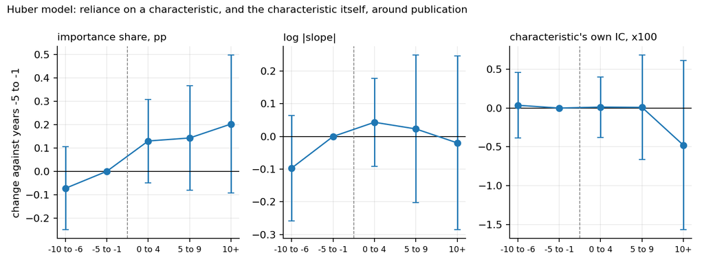

Figure 8: Huber model, binned event-time coefficients with 95 percent bands, relative to the five years before publication. Left: the model’s reliance on the characteristic, as its share of total importance. Middle: the size of its slope. Right: the characteristic’s own rank correlation with next month’s return.

What the table shows, counted. There are 10 model-outcome pairs in the post specification and 40 binned coefficients. Of the post coefficients, 2 have |t| above 2, the Huber importance in error units, the Huber importance share; of the binned coefficients, 0 do. Every post coefficient on importance is positive, which is the opposite sign from the competed-away story, but only the Huber ones are distinguishable from zero, at t = 2.82 in error units and t = 2.21 as a share of the year’s total; the trees and the network sit at t = 1.16 and 1.23. With this many outcomes looked at, two coefficients near t = 2 are what a search of this size turns up on its own, and the paper does not claim more.

The decomposition rows say that, if there is a Huber effect, it sits in the model and not in the characteristic: the slope grows weakly after publication ($\log|\beta|$ by 0.075, t = 0.83; $|\beta|$ by 2.4 basis points, t = 1.68), and the characteristic’s own correlation with next month’s return does not move (+0.092 on the IC × 100, t = 0.39; -0.004 on its absolute value, t = -0.03). A published characteristic has, by construction, a long in-sample record in the training data, and an expanding-window regression weights it accordingly, which would produce this pattern without any change in the characteristic itself.

Two things stand against reading the post coefficient as a publication effect. The earliest bin, six to ten years before publication, is below the reference for the Huber importance (t = -1.18), which is the pattern of a rise already under way before the paper appears; working papers circulate for years before a journal issue, and the publication year in the characteristic list is a late date for the event. And publication is staggered, so this is a two-way fixed effects event study with the weighting problem of Section 4.4. The same Sun and Abraham (2021) estimator is run here, on the same outcomes.

**read the Sun-Abraham estimates written by 08_stage1_eventtime.py**

```python
sa7 = pd.read_csv(OUT / "stage1_sunabraham.csv")
SA7_CUTOFFS = list(dict.fromkeys(sa7["control_cutoff"]))
SA7_MAIN = SA7_CUTOFFS[0]

def sa7_row(model, outcome, cutoff, est, term="post"):
    r = sa7[(sa7["model"] == model) & (sa7["outcome"] == outcome) & (sa7["control_cutoff"] == cutoff)
            & (sa7["estimator"] == est) & (sa7["term"] == term)]
    return r.iloc[0]

sa7_posts = sa7[sa7["term"] == "post"]
N7 = {c: int(((sa7_posts["control_cutoff"] == c) & (sa7_posts["estimator"] == "sun_abraham")).sum()) for c in SA7_CUTOFFS}
M7 = {c: int(((sa7_posts["control_cutoff"] == c) & (sa7_posts["estimator"] == "sun_abraham")
              & (sa7_posts["t"].abs() > 2)).sum()) for c in SA7_CUTOFFS}
h_main = sa7_row("huber", "imp_bp", SA7_MAIN, "sun_abraham")
h_share = sa7_row("huber", "share", SA7_MAIN, "sun_abraham")
h_pool = sa7_row("huber", "imp_bp", SA7_MAIN, "twfe_pooled")
h_static = sa7_row("huber", "imp_bp", SA7_MAIN, "twfe_static")
```

The control cohort is the last-published one, the 19 characteristics published in 2016 or later, and the test years run to 2015; a later cutoff, 2018, is reported beside it. The 21 characteristics that were already public in 1995 have no untreated year in the window and leave the estimation; in the two-way regression above they contributed to the year effects only.

Table 16: The post average with the Sun-Abraham estimator, by outcome and control cutoff, with the pooled two-way fixed effects bins and the single post dummy on the same sample. t-statistics in parentheses.

| Outcome | 2016: SA | 2016: TWFE bins | 2016: TWFE post | 2018: SA | 2018: TWFE bins | 2018: TWFE post |
| --- | --- | --- | --- | --- | --- | --- |
| Huber regression, importance (MSE × 10,000) | +0.006 (+0.2) | +0.002 (+0.1) | +0.017 (+1.5) | +0.001 (+0.0) | +0.007 (+0.3) | +0.018 (+1.6) |
| Huber regression, importance share (pp) | +0.000 (+0.0) | +0.013 (+0.2) | +0.078 (+1.2) | -0.026 (-0.2) | +0.046 (+0.5) | +0.076 (+1.3) |
| boosted trees, importance (MSE × 10,000) | -0.009 (-0.6) | -0.009 (-0.9) | -0.008 (-0.9) | -0.009 (-0.6) | -0.012 (-1.3) | -0.009 (-1.0) |
| boosted trees, importance share (pp) | -0.096 (-0.5) | -0.074 (-0.5) | -0.008 (-0.1) | +0.001 (+0.0) | -0.092 (-0.7) | -0.046 (-0.4) |
| network, 3 layers, importance (MSE × 10,000) | -0.004 (-0.1) | -0.006 (-0.2) | -0.006 (-0.3) | -0.004 (-0.1) | -0.009 (-0.3) | -0.004 (-0.2) |
| network, 3 layers, importance share (pp) | +0.035 (+0.3) | +0.032 (+0.2) | +0.054 (+0.5) | +0.034 (+0.2) | +0.049 (+0.3) | +0.047 (+0.5) |
| Huber slope, log of absolute value | -0.156 (-1.3) | -0.069 (-0.6) | +0.063 (+0.7) | -0.163 (-1.5) | -0.047 (-0.4) | +0.100 (+1.1) |
| Huber slope, absolute value in bp | -1.830 (-0.9) | -1.069 (-0.6) | +1.759 (+1.2) | -2.465 (-1.4) | -0.571 (-0.3) | +1.966 (+1.4) |
| characteristic’s own IC × 100 | +0.299 (+0.8) | +0.239 (+0.8) | +0.134 (+0.6) | +0.150 (+0.3) | +0.166 (+0.6) | +0.079 (+0.4) |
| characteristic’s own IC, absolute value × 100 | +0.212 (+0.9) | +0.170 (+1.0) | -0.089 (-0.7) | +0.064 (+0.3) | +0.091 (+0.6) | -0.117 (-1.0) |

Samples: cutoff 2016: test years to 2015, 113 treated and 19 control characteristics; cutoff 2018: test years to 2017, 124 treated and 8 control characteristics. The conservative covariance applies to 20 of the 20 Sun-Abraham cells and 8 of the 40 two-way fixed effects cells.

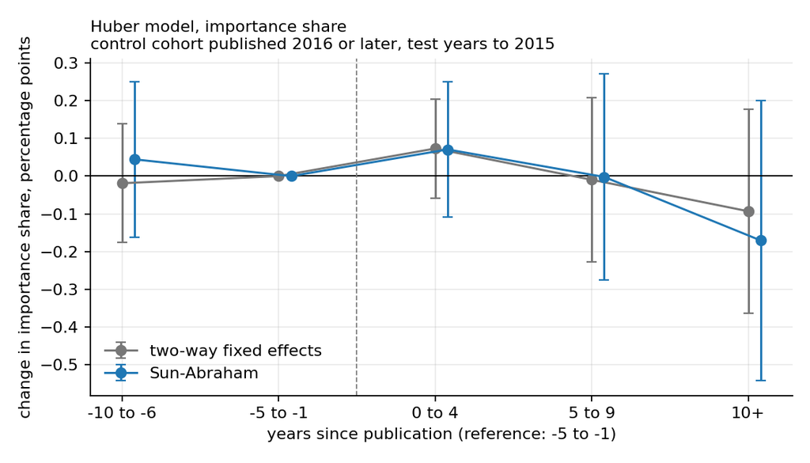

Figure 9: Huber importance share in event time, main cutoff, with 95 percent bands. Grey: pooled two-way fixed effects on the same sample. Blue: Sun-Abraham.

The first-pass estimate does not survive. With the cohort-robust estimator the Huber post average is +0.006 in error units (t = +0.22) and +0.000 percentage points of the year’s share (t = +0.00), and of the 10 model-outcome pairs 0 clear |t| = 2 at the main cutoff and 0 at the other. The two-way fixed effects regression gives the same answer once it is run on the sample the cohort-robust estimator can use: the binned version at +0.002 (t = 0.11), the single post dummy at +0.017 (t = 1.47). The t = 2.8 of Table 15 was carried by the characteristics public before the first test year, which have no untreated years, and by the test years after 2015, which have no not-yet-published characteristic to compare against. Neither is a comparison the estimator built for staggered dates can make. The section’s event-time result is therefore a null: on the comparisons that are clean, a model refit each year does not change how much it leans on a characteristic when the characteristic’s paper appears, in either direction.

# 8 What the design cannot do, and what comes next

## 8.1 Calendar time and staggered treatment

Publication arrives at a different date for every signal, so Equation 1 is a two-way fixed effects regression with staggered adoption. Goodman-Bacon (2021) shows that such an estimator is a weighted average of all possible two-group comparisons, including comparisons that use already-published signals as controls for later-published ones. When the effect varies across signals or evolves over time, and decay that continues for years after publication is an effect that evolves, those comparisons enter with the wrong sign. Section 4.4 runs the Sun and Abraham (2021) estimator, which uses only not-yet-published signals as controls and absorbs the calendar-time decline with month effects, and it takes the post-publication coefficient to zero against the five years before publication. The price is the window: with no never-published signal the last decade of data has no control and drops out. A stacked regression with one clean window per cohort (Cengiz et al. 2019), and the Callaway and Sant’Anna (2021) estimator with not-yet-published signals as controls, are the remaining checks.

Regression discontinuity does not apply. It needs a running variable with a cutoff and units that cannot manipulate their position around it. Here the running variable would be calendar time, the cutoff is anticipated, since working papers circulate for years before a journal issue appears, and authors have some control over timing. Anticipation alone pushes part of the decay before the event and biases the estimate toward zero, so the post-publication decline measured here is a lower bound on the true one.

## 8.2 How fast, and to what floor

A three-window average says the edge fell. It does not say how quickly, or whether it fell to zero. The simple route fits

$$\alpha_t \;=\; \phi + (\alpha_0 - \phi)\,e^{-\lambda t}
\qquad\Longrightarrow\qquad
\text{half-life} \;=\; \frac{\ln 2}{\lambda}$$

per signal, with $\phi$ the floor. Grossman and Stiglitz (1980) says the floor should be positive, so estimating it tests that prediction. The better route is a state-space model,

$$r_t = \alpha_t + \varepsilon_t, \qquad
\alpha_t = \phi_i + \rho_i(\alpha_{t-1} - \phi_i) + \eta_t ,$$

estimated by the Kalman filter and maximum likelihood (Durbin and Koopman 2012), which returns the floor and the half-life $\ln 2 / (-\ln \rho_i)$ with standard errors from one estimation.

## 8.3 Who dies fast

The cross-section is where the arbitrage story becomes testable: decay should be faster where arbitrage is cheaper and where more capital has arrived. Illiquidity, market capitalisation, idiosyncratic volatility, short interest and institutional ownership are all computable from the CRSP panel built for Section 5. The Jensen, Kelly and Pedersen global factor data would turn the same hypothesis into a cross-country test, and Jacobs and Müller (2020) suggest what to expect.

## 8.4 Open items

- Re-run on the McLean and Pontiff (2016) 97 to see whether the weaker channel separation is a composition effect.
- The Callaway and Sant’Anna (2021) estimator and a stacked regression beside the Sun and Abraham (2021) estimate of Section 4.4.
- Gross profitability as a third rebuilt signal; it needs Compustat and the CCM link.
- Decay in days: the same public-against-full comparison on daily portfolio returns built from the CRSP daily file, which is the horizon a trading desk means by the word.
- Sequence models on the stock-level panel, once the daily panel exists.

# 9 Reproducing this document

```bash
# The decay results need only the two free Chen and Zimmermann files in data/
quarto render paper/alpha-decay.qmd --to html

# The CRSP and forecasting sections read committed result files. To regenerate them:
python 03_crsp_pull.py          # WRDS subscription required
python 04_build_anomalies.py    # WRDS subscription required
python 05_ml_panel.py           # the two free files only, about ten minutes
python 06_jkp_pull.py           # the stock-level panel; WRDS subscription required
python 09_spreads.py            # closing quoted spreads from the CRSP daily file; WRDS
python 07_stage1_models.py --robust --crsp-only   # about a day on a laptop
python 08_stage1_eventtime.py   # the event-time tables and figures

# The version without the machine-learning section:
quarto render paper/alpha-decay.qmd --profile course
```

```python
# The three-window means recomputed here must match the ones 02_decay_panel.py wrote.
# If this assertion fires, the script and the paper have drifted apart.
saved = pd.read_csv(OUT / "result1_windows.csv", index_col=0)
assert saved.shape[0] == N_MATCHED, (saved.shape[0], N_MATCHED)
for c in ["in_sample", "post_sample", "post_pub"]:
    np.testing.assert_allclose(saved[c].mean(), table[c].mean(), rtol=1e-10)
print(f"verified against output/result1_windows.csv: "
      f"{N_MATCHED} signals, three windows match")
```

```
verified against output/result1_windows.csv: 189 signals, three windows match
```

# References

Abdi, Farshid, and Angelo Ranaldo. 2017. “A Simple Estimation of Bid-Ask Spreads from Daily Close, High, and Low Prices.” *Review of Financial Studies* 30 (12): 4437–80.

Banz, Rolf W. 1981. “The Relationship Between Return and Market Value of Common Stocks.” *Journal of Financial Economics* 9 (1): 3–18.

Callaway, Brantly, and Pedro H. C. Sant’Anna. 2021. “Difference-in-Differences with Multiple Time Periods.” *Journal of Econometrics* 225 (2): 200–230.

Cameron, A. Colin, Jonah B. Gelbach, and Douglas L. Miller. 2011. “Robust Inference with Multiway Clustering.” *Journal of Business and Economic Statistics* 29 (2): 238–49.

Cengiz, Doruk, Arindrajit Dube, Attila Lindner, and Ben Zipperer. 2019. “The Effect of Minimum Wages on Low-Wage Jobs.” *Quarterly Journal of Economics* 134 (3): 1405–54.

Chen, Andrew Y., and Mihail Velikov. 2023. “Zeroing in on the Expected Returns of Anomalies.” *Journal of Financial and Quantitative Analysis* 58 (3): 968–1004.

Chen, Andrew Y., and Tom Zimmermann. 2022. “Open Source Cross-Sectional Asset Pricing.” *Critical Finance Review* 11 (2): 207–64.

Chordia, Tarun, Avanidhar Subrahmanyam, and Qing Tong. 2014. “Have Capital Market Anomalies Attenuated in the Recent Era of High Liquidity and Trading Activity?” *Journal of Accounting and Economics* 58 (1): 41–58.

Chung, Kee H., and Hao Zhang. 2014. “A Simple Approximation of Intraday Spreads Using Daily Data.” *Journal of Financial Markets* 17: 94–120.

Corwin, Shane A., and Paul Schultz. 2012. “A Simple Way to Estimate Bid-Ask Spreads from Daily High and Low Prices.” *Journal of Finance* 67 (2): 719–60.

Daniel, Kent, and Tobias J. Moskowitz. 2016. “Momentum Crashes.” *Journal of Financial Economics* 122 (2): 221–47.

Diebold, Francis X., and Roberto S. Mariano. 1995. “Comparing Predictive Accuracy.” *Journal of Business and Economic Statistics* 13 (3): 253–63.

Durbin, James, and Siem Jan Koopman. 2012. *Time Series Analysis by State Space Methods*. 2nd ed. Oxford University Press.

Falck, Antoine, Adam Rej, and David Thesmar. 2022. “When Do Systematic Strategies Decay?” *Quantitative Finance* 22 (11): 1955–69.

Frisch, Ragnar, and Frederick V. Waugh. 1933. “Partial Time Regressions as Compared with Individual Trends.” *Econometrica* 1 (4): 387–401.

Gârleanu, Nicolae, and Lasse Heje Pedersen. 2013. “Dynamic Trading with Predictable Returns and Transaction Costs.” *Journal of Finance* 68 (6): 2309–40.

Goodman-Bacon, Andrew. 2021. “Difference-in-Differences with Variation in Treatment Timing.” *Journal of Econometrics* 225 (2): 254–77.

Grossman, Sanford J., and Joseph E. Stiglitz. 1980. “On the Impossibility of Informationally Efficient Markets.” *American Economic Review* 70 (3): 393–408.

Gu, Shihao, Bryan Kelly, and Dacheng Xiu. 2020. “Empirical Asset Pricing via Machine Learning.” *Review of Financial Studies* 33 (5): 2223–73.

Jacobs, Heiko, and Sebastian Müller. 2020. “Anomalies Across the Globe: Once Public, No Longer Existent?” *Journal of Financial Economics* 135 (1): 213–30.

Jegadeesh, Narasimhan. 1990. “Evidence of Predictable Behavior of Security Returns.” *Journal of Finance* 45 (3): 881–98.

Jegadeesh, Narasimhan, and Sheridan Titman. 1993. “Returns to Buying Winners and Selling Losers: Implications for Stock Market Efficiency.” *Journal of Finance* 48 (1): 65–91.

Jensen, Theis Ingerslev, Bryan Kelly, and Lasse Heje Pedersen. 2023. “Is There a Replication Crisis in Finance?” *Journal of Finance* 78 (5): 2465–2518.

Ke, Guolin, Qi Meng, Thomas Finley, Taifeng Wang, Wei Chen, Weidong Ma, Qiwei Ye, and Tie-Yan Liu. 2017. “LightGBM: A Highly Efficient Gradient Boosting Decision Tree.” *Advances in Neural Information Processing Systems* 30: 3146–54.

Ledoit, Oliver, and Michael Wolf. 2008. “Robust Performance Hypothesis Testing with the Sharpe Ratio.” *Journal of Empirical Finance* 15 (5): 850–59.

Lovell, Michael C. 1963. “Seasonal Adjustment of Economic Time Series and Multiple Regression Analysis.” *Journal of the American Statistical Association* 58 (304): 993–1010.

McLean, R. David, and Jeffrey Pontiff. 2016. “Does Academic Research Destroy Stock Return Predictability?” *Journal of Finance* 71 (1): 5–32.

Newey, Whitney K., and Kenneth D. West. 1987. “A Simple, Positive Semi-Definite, Heteroskedasticity and Autocorrelation Consistent Covariance Matrix.” *Econometrica* 55 (3): 703–8.

Pedregosa, Fabian, Gaël Varoquaux, Alexandre Gramfort, Vincent Michel, Bertrand Thirion, Olivier Grisel, Mathieu Blondel, et al. 2011. “Scikit-Learn: Machine Learning in Python.” *Journal of Machine Learning Research* 12: 2825–30.

Petersen, Mitchell A. 2009. “Estimating Standard Errors in Finance Panel Data Sets: Comparing Approaches.” *Review of Financial Studies* 22 (1): 435–80.

Shleifer, Andrei, and Robert W. Vishny. 1997. “The Limits of Arbitrage.” *Journal of Finance* 52 (1): 35–55.

Shumway, Tyler. 1997. “The Delisting Bias in CRSP Data.” *Journal of Finance* 52 (1): 327–40.

Sun, Liyang, and Sarah Abraham. 2021. “Estimating Dynamic Treatment Effects in Event Studies with Heterogeneous Treatment Effects.” *Journal of Econometrics* 225 (2): 175–99.